# Лабораторна робота № 11. Двовимірне перетворення Фур'є та детектування контурів зображень

### Мета: Опанувати спектральний аналіз цифрових зображень за допомогою двовимірного дискретного перетворення Фур'є (2D-ДПФ), вивчити амплітудний та фазовий спектри, дослідити частотну фільтрацію (ідеальний, гаусів низькочастотний та високочастотний фільтри) і ефект Гіббса, а також порівняти градієнтні оператори Собеля й Шарра та детектор контурів Кенні з гістерезисною пороговою обробкою на задачі виділення границь мідних провідників друкованої плати.

#### *Варіант 2 (№ 22 у списку: $22 - 20 = 2$)*

### Виконав: Яцентюк Євгеній, група: КІ-24-1

[**GitHub**](https://github.com/kefir4ikk)

## 1. Імпорт бібліотек та налаштування стилю відображення

```python
%config InlineBackend.figure_format = 'png'
import os
import csv
import json
import cv2
import numpy as np
import matplotlib.pyplot as plt
from scipy import ndimage, signal
from scipy.special import ndtr

os.makedirs("figures", exist_ok=True)
os.makedirs("data", exist_ok=True)

plt.rcParams['font.family'] = 'DejaVu Sans'
plt.rcParams['figure.dpi'] = 80          # розмір рисунків у ноутбуці; у figures/ вони зберігаються з dpi = 200
plt.rcParams['axes.edgecolor'] = '#2b2b2b'
plt.rcParams['axes.linewidth'] = 1.0
plt.rcParams['grid.color'] = '#cccccc'
plt.rcParams['grid.linestyle'] = '--'
plt.rcParams['grid.alpha'] = 0.6

import scipy, matplotlib
print(f"NumPy: {np.__version__} | OpenCV: {cv2.__version__} | SciPy: {scipy.__version__} | Matplotlib: {matplotlib.__version__}")
```

```
NumPy: 2.5.3 | OpenCV: 5.0.0 | SciPy: 1.18.1 | Matplotlib: 3.11.2
```

## 2. Параметри варіанта 2 та постановка завдання

**Індивідуальне завдання (варіант 2):**

| Прикладна задача | Радіус зрізу $D_0$, px | Параметр гаусового фільтра $\sigma_f$ | Ядро Собеля $k$ | Пороги Кенні $[T_{low},\,T_{high}]$ | Цільовий контур |
| --- | --- | --- | --- | --- | --- |
| Дефектоскопія друкованої плати | 50 | 35.0 | 3 | [60, 180] | границі мідних провідників |

**Двовимірне ДПФ** зображення $f(x,y)$ розміром $M\times N$ та обернене перетворення:

$$F(u,v)=\sum_{x=0}^{M-1}\sum_{y=0}^{N-1}f(x,y)\,e^{-j2\pi\left(\frac{ux}{M}+\frac{vy}{N}\right)},\qquad f(x,y)=\frac{1}{MN}\sum_{u=0}^{M-1}\sum_{v=0}^{N-1}F(u,v)\,e^{j2\pi\left(\frac{ux}{M}+\frac{vy}{N}\right)}.$$

Спектр відображають як $S(u,v)=20\log_{10}(|F(u,v)|+1)$ після `fftshift`, коли нульова частота $F(0,0)=\sum f$ потрапляє в центр $(M/2,N/2)$. Ключові властивості, які перевіряються в роботі: рівність Парсеваля $\sum|f|^2=\frac1{MN}\sum|F|^2$, теорема зсуву (зсув зображення змінює лише фазу), теорема згортки $\mathcal F\{f*h\}=F\cdot H$.

**Частотні фільтри** з відстанню від центру $D(u,v)=\sqrt{(u-M/2)^2+(v-N/2)^2}$:

$$H_{ILPF}=\begin{cases}1,&D\le D_0\\0,&D>D_0\end{cases},\qquad H_{GLPF}=e^{-D^2/(2\sigma_f^2)},\qquad H_{GHPF}=1-H_{GLPF}.$$

Гаусів фільтр у частотній області відповідає гаусовому ядру в просторовій з $\sigma_x=\dfrac{N}{2\pi\sigma_f}$, для варіанта 2 — $\sigma_x=\dfrac{512}{2\pi\cdot35}=2.328$ px. Ідеальний фільтр має просторове ядро типу $J_1(2\pi D_0 r/N)/r$ з осциляціями, що й породжують ефект Гіббса: для ступінчастого краю перерегулювання дорівнює $\approx8.95$ % стрибка, а період пульсацій $\approx N/D_0=10.24$ px.

**Градієнтні оператори.** $G=\sqrt{G_x^2+G_y^2}$ або $|G_x|+|G_y|$, $\theta=\mathrm{atan2}(G_y,G_x)$. Ядра $3\times3$: Собель — ваги $(1,2,1)$, Шарр — $(3,10,3)$. Для порівняння в одних одиницях (інтенсивність/px) відгук на лінійну рампу одиничного нахилу дорівнює $8$ (Собель) і $32$ (Шарр), тому нормування — діленням на ці числа.

**Алгоритм Кенні:** згладжування гаусом $\to$ градієнти та кут $\to$ пригнічення немаксимумів (NMS) за квантованим напрямом $\to$ подвійний поріг $T_{low}<T_{high}$ $\to$ трасування гістерезисом (слабкі пікселі зберігаються лише в 8-зв'язній компоненті, що містить сильний піксель).

**Тестова сцена та оцінка якості.** Для кількісної оцінки синтезується плата $512\times512$ з відомою маскою міді. Еталонний контур — внутрішня межа маски міді товщиною 1 px. Піксель детектора вважається вірним (TP), якщо лежить не далі ніж 2 px від еталонного контуру. Повнота (recall) — частка еталонних пікселів, біля яких є піксель детектора (у межах 2 px). Окремо враховуються краї шовкографії (низькоконтрастна розмітка): це справжні краї на зображенні, але вони **не є цільовим контуром** (границями міді).

## 3. Базова тестова сцена та блоки 1-5 методички (скрипт `lab11_fft2d_edges.py`)

Цей розділ виконує **блоки 1-5 методички** на стандартній тестовій сцені $512\times512$ з параметрами варіанта 2 ($D_0=50$, $\sigma_f=35$, Собель $k=3$, пороги Кенні $[60,180]$ та три режими з методички $[30,80]$, $[50,150]$, $[120,220]$): **блок 1** — сцена (концентричні кола, повернутий прямокутник, штрихова решітка, промені, текст та одне слабоконтрастне кільце $+60$ рівнів, щоб пороги давали різні результати); **блок 2** — 2D-ДПФ, логарифмічний амплітудний та фазовий спектри; **блок 3** — ILPF, GLPF, GHPF; **блок 4** — градієнти Собеля та Шарра; **блок 5** — детектор Кенні. Код розділу — це повний вміст автономного скрипта `lab11_fft2d_edges.py` (запускається окремо командою `python lab11_fft2d_edges.py`); він зберігає `data/test_edge_scene.png`, `data/results_base_scene.json` та чотири рисунки `figures/fft2d_spectrum_analysis.png`, `figures/frequency_filtering_results.png`, `figures/sobel_scharr_gradients.png`, `figures/canny_thresholds_study.png`. Розділи 4-10 розвивають роботу на **прикладній задачі варіанта 2** — границях мідних провідників друкованої плати (рисунки з префіксом `pcb_`) з кількісною оцінкою за еталонним контуром, перевірками та додатковими дослідженнями.

```
Блок 1. Сцена 512x512: яскравість [11, 217], еталонний контур 11437 px
Блок 2. Спектр 512x512, максимум 143.4 дБ у позиції (256, 256); Парсеваль: 0.0e+00; обернене ДПФ: 1.1e-13
```

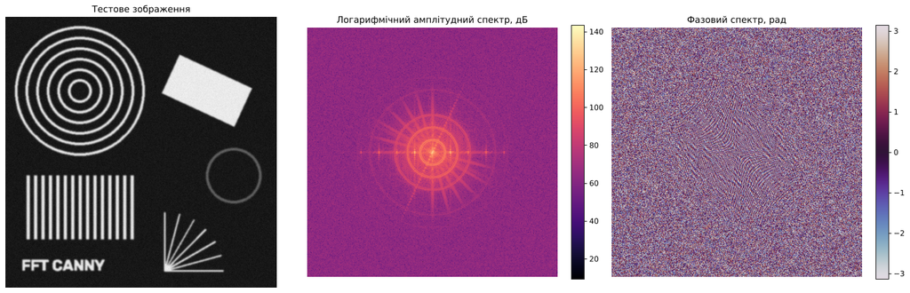

```
Блок 3. D0 = 50, sigma_f = 35.0:
   ILPF: діапазон результату [-155.6, 226.5]; PSNR відносно кадру без шуму: 25.27 дБ (кадр після фільтра без шуму: 25.28 дБ)
   GLPF: діапазон результату [27.9, 201.6]; PSNR відносно кадру без шуму: 24.16 дБ (кадр після фільтра без шуму: 24.16 дБ)
   GHPF: діапазон [-77.7, 78.7]; GLPF + GHPF = вихідне: похибка 1.1e-13
```

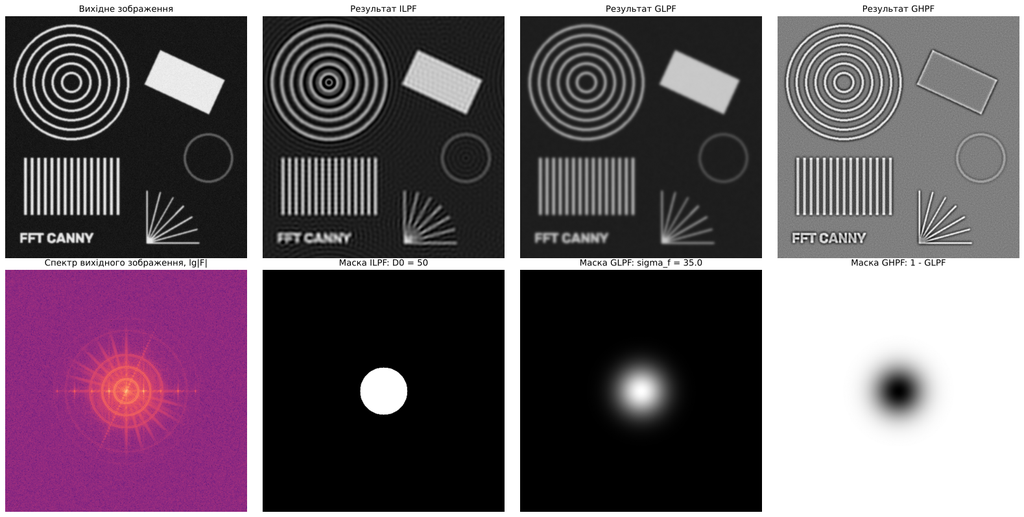

```
Блок 4. Собель (k = 3): max |G| = 455.6, середнє 68.82; Шарр: max |G| = 1859.9, середнє 281.51 (відношення середніх 4.09, коефіцієнти підсилення рампи 32/8 = 4)
```

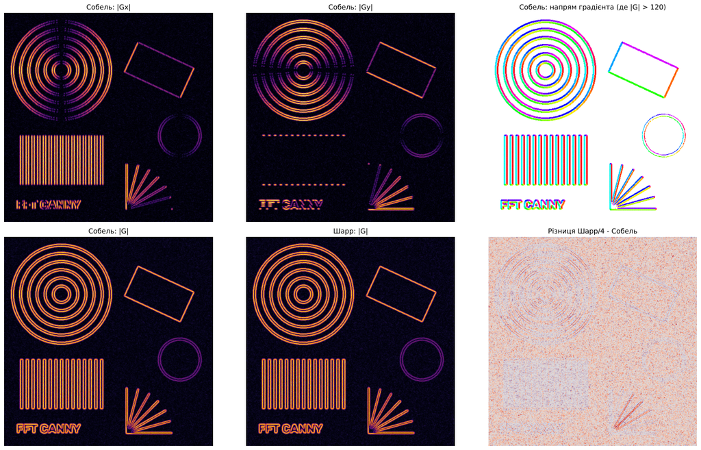

```
Блок 5. Детектор Кенні (допуск 2 px до еталонного контуру):
   Режим                     пікселів      TP   хибні       P  recall      F1
   Варіант 2: [60, 180]         12810   12810       0   1.000   0.949   0.974
   Режим [30, 80]               13532   13531       1   1.000   0.999   1.000
   Режим [50, 150]              13529   13529       0   1.000   0.999   1.000
   Режим [120, 220]             12790   12790       0   1.000   0.948   0.973
```

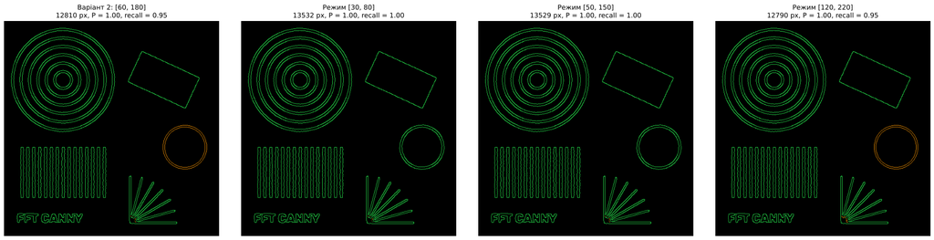

```
Готово: data/test_edge_scene.png, data/results_base_scene.json, figures/*.png
```

```python
# -*- coding: utf-8 -*-
"""
Лабораторна робота № 11. Двовимірне перетворення Фур'є та детектування контурів зображень.
Виконав: Яцентюк Євгеній, група КІ-24-1. Варіант 2 (№ 22 у списку: 22 - 20 = 2).

Параметри варіанта 2: D0 = 50 px (ILPF), sigma_f = 35.0 (GLPF), ядро Собеля k = 3,
пороги Кенні [T_low, T_high] = [60, 180], цільовий контур - границі мідних провідників.

Блоки: 1 - тестова сцена; 2 - 2D-ДПФ та спектри; 3 - частотна фільтрація ILPF/GLPF/GHPF;
4 - градієнти Собеля та Шарра; 5 - детектор Кенні з трьома режимами порогів (та режимом варіанта 2).
Запуск: python lab11_fft2d_edges.py
"""
import os
import json
import cv2
import numpy as np
import matplotlib.pyplot as plt

N, D0, SIGF, K_SOBEL = 512, 50, 35.0, 3
T_LOW, T_HIGH = 60, 180
MODES = [("Варіант 2: [60, 180]", 60, 180), ("Режим [30, 80]", 30, 80), ("Режим [50, 150]", 50, 150), ("Режим [120, 220]", 120, 220)]
SEED = 11


def make_scene(n=N, seed=SEED):
    """Блок 1. Тестова сцена n x n: концентричні кола, повернутий прямокутник, штрихова решітка, промені, текст
    та одне слабоконтрастне кільце (щоб пороги Кенні давали різні результати)."""
    rng = np.random.default_rng(seed)
    m = np.zeros((n, n), np.uint8)
    for r in range(20, 130, 20):
        cv2.circle(m, (140, 140), r, 255, 3)                                    # концентричні кола
    box = cv2.boxPoints(((380, 140), (150, 80), 25)).astype(np.int32)
    cv2.fillPoly(m, [box], 255)                                                 # повернутий прямокутник
    for x in range(40, 250, 14):
        cv2.rectangle(m, (x, 300), (x + 5, 420), 255, -1)                       # штрихова решітка
    for a in range(0, 91, 15):
        t = np.deg2rad(a)
        cv2.line(m, (300, 480), (int(300 + 110 * np.cos(t)), int(480 - 110 * np.sin(t))), 255, 2)   # промені
    cv2.putText(m, "FFT CANNY", (30, 480), cv2.FONT_HERSHEY_SIMPLEX, 1.0, 255, 2, cv2.LINE_8)        # текст
    faint = np.zeros((n, n), np.uint8)
    cv2.circle(faint, (430, 300), 50, 255, 3)                                   # слабоконтрастне кільце (+60 рівнів)
    base = 30.0 + 170.0 * (m > 0) + 60.0 * ((faint > 0) & (m == 0))
    m = np.maximum(m, faint)
    clean = cv2.GaussianBlur(base, (0, 0), 1.2)                                 # розмиття оптики
    noisy = clean + rng.normal(0.0, 4.0, (n, n))                                # гаусів шум
    gray = np.clip(np.round(noisy), 0, 255).astype(np.uint8)
    cross = cv2.getStructuringElement(cv2.MORPH_CROSS, (3, 3))
    gt = (m > 0) & ~(cv2.erode(m, cross) > 0)                                   # еталонний контур: внутрішня межа маски
    return gray, clean, m, gt


def freq_grid(n=N):
    u = np.arange(n) - n // 2
    V, U = np.meshgrid(u, u)
    return np.hypot(U, V)


def apply_filter(a, Hc):
    return np.real(np.fft.ifft2(np.fft.ifftshift(Hc) * np.fft.fft2(a)))


def psnr(a, b, peak=255.0):
    return float(10 * np.log10(peak ** 2 / np.mean((a - b) ** 2)))


def evaluate(edge, gt, tol=2.0):
    """Точність/повнота контуру: піксель вірний, якщо лежить не далі tol px від еталонного контуру."""
    e = edge > 0
    dt_gt = cv2.distanceTransform((~gt).astype(np.uint8), cv2.DIST_L2, 5)
    dt_e = cv2.distanceTransform((~e).astype(np.uint8), cv2.DIST_L2, 5)
    tp = int((e & (dt_gt <= tol)).sum())
    prec = tp / max(int(e.sum()), 1)
    rec = float((gt & (dt_e <= tol)).sum() / gt.sum())
    return dict(n=int(e.sum()), tp=tp, fp=int(e.sum()) - tp, prec=prec, rec=rec, f1=2 * prec * rec / max(prec + rec, 1e-12))


def main():
    os.makedirs("data", exist_ok=True)
    os.makedirs("figures", exist_ok=True)
    plt.rcParams['font.family'] = 'DejaVu Sans'

    res = {}
    # ---------------- Блок 1: тестова сцена
    gray, clean, mask, gt = make_scene()
    img = gray.astype(np.float64)
    cv2.imwrite("data/test_edge_scene.png", gray)
    print(f"Блок 1. Сцена {N}x{N}: яскравість [{gray.min()}, {gray.max()}], еталонний контур {int(gt.sum())} px")

    # ---------------- Блок 2: 2D-ДПФ, амплітудний та фазовий спектри
    F = np.fft.fft2(img)
    Fs = np.fft.fftshift(F)
    S = 20 * np.log10(np.abs(Fs) + 1)
    phase = np.angle(Fs)
    parseval = abs((img ** 2).sum() - (np.abs(F) ** 2).sum() / N ** 2) / (img ** 2).sum()
    inv_err = np.abs(np.real(np.fft.ifft2(F)) - img).max()
    dc = np.unravel_index(np.argmax(np.abs(Fs)), Fs.shape)
    print(f"Блок 2. Спектр {S.shape[0]}x{S.shape[1]}, максимум {S.max():.1f} дБ у позиції {tuple(int(i) for i in dc)}; Парсеваль: {parseval:.1e}; обернене ДПФ: {inv_err:.1e}")
    fig, axes = plt.subplots(1, 3, figsize=(17, 5.4))
    axes[0].imshow(gray, cmap='gray'); axes[0].set_title("Тестове зображення")
    im1 = axes[1].imshow(S, cmap='magma'); axes[1].set_title("Логарифмічний амплітудний спектр, дБ"); plt.colorbar(im1, ax=axes[1], fraction=0.046)
    im2 = axes[2].imshow(phase, cmap='twilight', vmin=-np.pi, vmax=np.pi); axes[2].set_title("Фазовий спектр, рад"); plt.colorbar(im2, ax=axes[2], fraction=0.046)
    for a in axes: a.axis('off')
    plt.tight_layout(); plt.savefig("figures/fft2d_spectrum_analysis.png", dpi=200); plt.show()

    res['spectrum'] = dict(max_db=float(S.max()), max_pos=[int(i) for i in dc], parseval_rel=float(parseval), inverse_err=float(inv_err))

    # ---------------- Блок 3: ILPF, GLPF, GHPF
    D = freq_grid()
    H = {"ILPF": (D <= D0).astype(float), "GLPF": np.exp(-D ** 2 / (2 * SIGF ** 2))}
    H["GHPF"] = 1.0 - H["GLPF"]
    out = {k: apply_filter(img, v) for k, v in H.items()}
    clean_lp = {k: apply_filter(clean, H[k]) for k in ("ILPF", "GLPF")}
    print(f"Блок 3. D0 = {D0}, sigma_f = {SIGF}:")
    for k in ("ILPF", "GLPF"):
        print(f"   {k}: діапазон результату [{out[k].min():.1f}, {out[k].max():.1f}]; PSNR відносно кадру без шуму: {psnr(out[k], clean):.2f} дБ (кадр після фільтра без шуму: {psnr(clean_lp[k], clean):.2f} дБ)")
    print(f"   GHPF: діапазон [{out['GHPF'].min():.1f}, {out['GHPF'].max():.1f}]; GLPF + GHPF = вихідне: похибка {np.abs(out['GLPF'] + out['GHPF'] - img).max():.1e}")
    res['filters'] = {k: dict(min=float(out[k].min()), max=float(out[k].max())) for k in out}
    for k in ('ILPF', 'GLPF'): res['filters'][k]['psnr_vs_noise_free'] = psnr(out[k], clean)
    fig, axes = plt.subplots(2, 4, figsize=(20, 10))
    axes[0, 0].imshow(gray, cmap='gray'); axes[0, 0].set_title("Вихідне зображення")
    for j, k in enumerate(("ILPF", "GLPF", "GHPF")):
        if k == "GHPF": axes[0, j + 1].imshow(out[k], cmap='gray', vmin=-60, vmax=60)
        else: axes[0, j + 1].imshow(np.clip(out[k], 0, 255), cmap='gray', vmin=0, vmax=255)
        axes[0, j + 1].set_title(f"Результат {k}")
        axes[1, j + 1].imshow(H[k], cmap='gray', vmin=0, vmax=1); axes[1, j + 1].set_title(f"Маска {k}: " + {"ILPF": f"D0 = {D0}", "GLPF": f"sigma_f = {SIGF}", "GHPF": "1 - GLPF"}[k])
    axes[1, 0].imshow(np.log10(np.abs(Fs) + 1), cmap='magma'); axes[1, 0].set_title("Спектр вихідного зображення, lg|F|")
    for a in axes.ravel(): a.axis('off')
    plt.tight_layout(); plt.savefig("figures/frequency_filtering_results.png", dpi=200); plt.show()

    # ---------------- Блок 4: градієнти Собеля та Шарра
    sx = cv2.Sobel(img, cv2.CV_64F, 1, 0, ksize=K_SOBEL); sy = cv2.Sobel(img, cv2.CV_64F, 0, 1, ksize=K_SOBEL)
    cx = cv2.Scharr(img, cv2.CV_64F, 1, 0); cy = cv2.Scharr(img, cv2.CV_64F, 0, 1)
    mag_s, mag_c = np.hypot(sx, sy), np.hypot(cx, cy)
    ang_s = np.degrees(np.arctan2(sy, sx))
    print(f"Блок 4. Собель (k = {K_SOBEL}): max |G| = {mag_s.max():.1f}, середнє {mag_s.mean():.2f}; Шарр: max |G| = {mag_c.max():.1f}, середнє {mag_c.mean():.2f} (відношення середніх {mag_c.mean() / mag_s.mean():.2f}, коефіцієнти підсилення рампи 32/8 = 4)")
    res['gradients'] = dict(sobel_max=float(mag_s.max()), sobel_mean=float(mag_s.mean()), scharr_max=float(mag_c.max()), scharr_mean=float(mag_c.mean()))
    fig, axes = plt.subplots(2, 3, figsize=(18, 11))
    axes[0, 0].imshow(np.abs(sx), cmap='inferno'); axes[0, 0].set_title("Собель: |Gx|")
    axes[0, 1].imshow(np.abs(sy), cmap='inferno'); axes[0, 1].set_title("Собель: |Gy|")
    axes[0, 2].imshow(np.where(mag_s > 120, ang_s, np.nan), cmap='hsv', vmin=-180, vmax=180); axes[0, 2].set_title("Собель: напрям градієнта (де |G| > 120)")
    axes[1, 0].imshow(mag_s, cmap='inferno'); axes[1, 0].set_title("Собель: |G|")
    axes[1, 1].imshow(mag_c, cmap='inferno'); axes[1, 1].set_title("Шарр: |G|")
    axes[1, 2].imshow(mag_c / 4 - mag_s, cmap='coolwarm', vmin=-np.percentile(np.abs(mag_c / 4 - mag_s), 99.9), vmax=np.percentile(np.abs(mag_c / 4 - mag_s), 99.9)); axes[1, 2].set_title("Різниця Шарр/4 - Собель")
    for a in axes.ravel(): a.axis('off')
    plt.tight_layout(); plt.savefig("figures/sobel_scharr_gradients.png", dpi=200); plt.show()

    # ---------------- Блок 5: детектор Кенні, режими порогів
    blur = cv2.GaussianBlur(gray, (5, 5), 1.0)
    res['canny'] = {}
    fig, axes = plt.subplots(1, 4, figsize=(24, 6.4))
    print("Блок 5. Детектор Кенні (допуск 2 px до еталонного контуру):")
    print(f"   {'Режим':<24}{'пікселів':>10}{'TP':>8}{'хибні':>8}{'P':>8}{'recall':>8}{'F1':>8}")
    for ax, (nm, lo, hi) in zip(axes, MODES):
        e = cv2.Canny(blur, lo, hi, apertureSize=K_SOBEL, L2gradient=False)
        r = evaluate(e, gt); res['canny'][nm] = dict(t_low=lo, t_high=hi, **r)
        print(f"   {nm:<24}{r['n']:10d}{r['tp']:8d}{r['fp']:8d}{r['prec']:8.3f}{r['rec']:8.3f}{r['f1']:8.3f}")
        rgb = np.zeros((N, N, 3), np.float32)
        dt_e = cv2.distanceTransform((e == 0).astype(np.uint8), cv2.DIST_L2, 5)
        dt_gt = cv2.distanceTransform((~gt).astype(np.uint8), cv2.DIST_L2, 5)
        rgb[gt & (dt_e > 2)] = (1.0, 0.6, 0.0)
        rgb[(e > 0) & (dt_gt <= 2)] = (0.15, 0.9, 0.3)
        rgb[(e > 0) & (dt_gt > 2)] = (1.0, 0.1, 0.1)
        ax.imshow(rgb); ax.set_title(f"{nm}\n{r['n']} px, P = {r['prec']:.2f}, recall = {r['rec']:.2f}"); ax.axis('off')
    fig.subplots_adjust(left=0.01, right=0.99, bottom=0.02, top=0.86, wspace=0.03)
    plt.savefig("figures/canny_thresholds_study.png", dpi=200); plt.show()
    with open("data/results_base_scene.json", "w", encoding="utf-8") as f:
        json.dump(res, f, ensure_ascii=False, indent=1)
    print("Готово: data/test_edge_scene.png, data/results_base_scene.json, figures/*.png")


main()
```

## 4. Генерація тестової сцени друкованої плати та еталонного контуру

Сцена містить: три горизонтальні та дві вертикальні доріжки різної ширини (6-10 px) з круглими контактними майданчиками та отворами, діагональну доріжку під $45^\circ$, повернутий на $30^\circ$ прямокутний полігон «землі», ряд з 10 виводів мікросхеми з кроком 16 px (гратка просторової частоти $N/16=32$ циклів на кадр) і шовкографію (контур мікросхеми й текст, контраст лише $+35$ рівнів). Ділянка доріжки довжиною 120 px **потьмяніла** (окиснена мідь, амплітуда міді плавно знижується до 40 %), щоб на ній краї були слабкими. Кадр: розмиття оптики $\sigma=1.5$ px, нерівномірне освітлення (множник від $0.63$ до $1.0$) та гаусів шум $\sigma_n=6$ рівнів.

```
Сцена 512x512: мідь 23741 px, еталонний контур 5118 px, контур шовкографії 1565 px, контур потьмянілої ділянки 252 px
Яскравість кадру: [4, 219], середнє 46.9; множник освітлення 0.63 ... 1.00; шум sigma = 6.0
Контраст міді до підкладки: 165 рівнів (у потьмянілій ділянці до 66), шовкографії 35
```

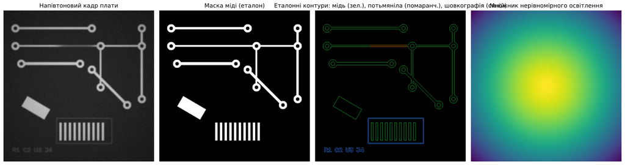

```python
RNG_SEED = 11
rng = np.random.default_rng(RNG_SEED)

def build_scene(N=512):
    m = np.zeros((N, N), np.uint8)
    rect = lambda x0, y0, x1, y1: cv2.rectangle(m, (x0, y0), (x1, y1), 255, -1)
    # доріжки
    rect(40, 56, 300, 63)         # T1, ширина 8
    rect(40, 117, 470, 122)       # T2, ширина 6 (на ній потьмяніла ділянка)
    rect(60, 175, 260, 184)       # T3, ширина 10
    rect(466, 60, 473, 300)       # V1, ширина 8
    rect(327, 120, 332, 260)      # V2, ширина 6
    cv2.line(m, (300, 200), (420, 320), 255, 7, cv2.LINE_8)    # діагональна доріжка
    box = cv2.boxPoints(((110, 330), (90, 40), 30)).astype(np.int32)
    cv2.fillPoly(m, [box], 255)   # повернутий полігон «землі»
    for i in range(10):           # виводи мікросхеми, крок 16 px, ширина 8 px
        rect(190 + 16 * i, 380, 190 + 16 * i + 7, 440)
    pads = [(40, 60), (300, 60), (40, 120), (470, 120), (60, 180), (260, 180), (470, 60), (470, 300),
            (330, 120), (330, 260), (300, 200), (420, 320)]
    for (cx, cy) in pads:
        cv2.circle(m, (cx, cy), 14, 255, -1)
    for (cx, cy) in pads:
        cv2.circle(m, (cx, cy), 6, 0, -1)       # отвори у майданчиках
    # шовкографія (низький контраст)
    silk = np.zeros((N, N), np.uint8)
    cv2.rectangle(silk, (180, 365), (368, 450), 255, 2)
    cv2.putText(silk, "R1  C2  U3  J4", (30, 480), cv2.FONT_HERSHEY_SIMPLEX, 0.7, 255, 2, cv2.LINE_8)
    silk[m > 0] = 0
    return m, silk

N = 512
mask, silk = build_scene(N)

# потьмяніла ділянка (плавне зниження амплітуди міді до 50 %)
dim_box = np.zeros((N, N)); dim_box[100:140, 190:310] = 1.0
dim_soft = ndimage.gaussian_filter(dim_box, 12.0); dim_soft /= dim_soft.max()
amp_map = 1.0 - 0.6 * dim_soft
dim_roi = ndimage.gaussian_filter(dim_box, 12.0) > 0.35      # область, у якій амплітуда міді < ~67 %

# напівтонова модель кадру
SUBSTRATE, COPPER, SILK_LVL, SIGMA_OPT, SIGMA_N = 40.0, 205.0, 35.0, 1.5, 6.0
base = SUBSTRATE + (COPPER - SUBSTRATE) * (mask > 0) * amp_map + SILK_LVL * (silk > 0)
yy, xx = np.mgrid[0:N, 0:N]
illum = 1.0 - 0.37 * np.clip(np.hypot(xx - N / 2, yy - N / 2) / np.hypot(N / 2, N / 2), 0, 1) ** 1.5
g_nf = ndimage.gaussian_filter(base, SIGMA_OPT) * illum             # кадр без шуму (float)
noise = rng.normal(0.0, SIGMA_N, (N, N))
gray = np.clip(np.round(g_nf + noise), 0, 255).astype(np.uint8)    # кадр, який бачить детектор
img = gray.astype(np.float64)

# еталонні контури: внутрішня межа маски (4-сусідство)
cross3 = cv2.getStructuringElement(cv2.MORPH_CROSS, (3, 3))
gt = (mask > 0) & ~(cv2.erode(mask, cross3) > 0)
silk_b = (silk > 0) & ~(cv2.erode(silk, cross3) > 0)
gt_dim = gt & dim_roi

dt_gt = cv2.distanceTransform((~gt).astype(np.uint8), cv2.DIST_L2, 5)
dt_silk = cv2.distanceTransform((~silk_b).astype(np.uint8), cv2.DIST_L2, 5)
valid = np.zeros((N, N), bool); valid[4:-4, 4:-4] = True

print(f"Сцена {N}x{N}: мідь {int((mask > 0).sum())} px, еталонний контур {int(gt.sum())} px, контур шовкографії {int(silk_b.sum())} px, контур потьмянілої ділянки {int(gt_dim.sum())} px")
print(f"Яскравість кадру: [{gray.min()}, {gray.max()}], середнє {gray.mean():.1f}; множник освітлення {illum.min():.2f} ... {illum.max():.2f}; шум sigma = {SIGMA_N}")
print(f"Контраст міді до підкладки: {COPPER - SUBSTRATE:.0f} рівнів (у потьмянілій ділянці до {(COPPER - SUBSTRATE) * amp_map[120, 250]:.0f}), шовкографії {SILK_LVL:.0f}")

fig, axes = plt.subplots(1, 4, figsize=(18, 4.8))
axes[0].imshow(gray, cmap='gray', vmin=0, vmax=255); axes[0].set_title("Напівтоновий кадр плати")
axes[1].imshow(mask, cmap='gray'); axes[1].set_title("Маска міді (еталон)")
ov = np.zeros((N, N, 3)); ov[gt] = (0.1, 0.8, 0.2); ov[silk_b] = (0.2, 0.5, 1.0); ov[gt_dim] = (1.0, 0.6, 0.0)
axes[2].imshow(ov); axes[2].set_title("Еталонні контури: мідь (зел.), потьмяніла (помаранч.), шовкографія (синій)")
axes[3].imshow(illum, cmap='viridis'); axes[3].set_title("Множник нерівномірного освітлення")
for a in axes: a.axis('off')
plt.tight_layout(); plt.show()
```

## 5. Двовимірне ДПФ: спектри, властивості та роль фази

Спочатку власна реалізація 2D-ДПФ як добутку матриць $F=W f W$ ($W_{kn}=e^{-j2\pi kn/N}$, матриця симетрична) порівнюється з `numpy.fft.fft2`. Потім перевіряються рівність Парсеваля, значення $F(0,0)$, положення нульової частоти після `fftshift` та теорема зсуву. Амплітудний спектр показується в логарифмічному масштабі. Для демонстрації ролі фази амплітуда однієї сцени поєднується з фазою іншої (опорна сцена: концентричні кільця, промені та гратка).

```python
# --- власна реалізація 2D-ДПФ та перевірки
k = np.arange(N)
Wm = np.exp(-2j * np.pi * np.outer(k, k) / N)
F_own = Wm @ img @ Wm
F = np.fft.fft2(img)
err_dft = np.abs(F_own - F).max() / np.abs(F).max()
rec = np.real(np.fft.ifft2(F))
err_inv = np.abs(rec - img).max()
parseval_lhs = float((img ** 2).sum()); parseval_rhs = float((np.abs(F) ** 2).sum() / N ** 2)
dc_err = abs(F[0, 0].real - img.sum()) / img.sum()
Fs = np.fft.fftshift(F)
amp, phase = np.abs(Fs), np.angle(Fs)
S_db = 20 * np.log10(amp + 1)
dc_pos = tuple(int(i) for i in np.unravel_index(np.argmax(amp), amp.shape))

# теорема зсуву: циклічний зсув міняє лише фазу
shifted = np.roll(img, (37, -23), axis=(0, 1))
amp_shift_err = np.abs(np.abs(np.fft.fft2(shifted)) - np.abs(F)).max() / np.abs(F).max()
ph_exp = np.angle(F * np.exp(-2j * np.pi * (np.arange(N)[:, None] * 37 + np.arange(N)[None, :] * (-23)) / N))
shift_phase_err = np.abs(np.exp(1j * np.angle(np.fft.fft2(shifted))) - np.exp(1j * ph_exp)).max()

# динамічний діапазон: чому потрібен логарифм
amp_nodc = amp.copy(); amp_nodc[N // 2, N // 2] = 0
share_lin = float((amp > 0.01 * amp.max()).sum() / amp.size * 100)
dyn_range_db = 20 * np.log10(amp.max() / np.median(amp))

# радіальна статистика та частка енергії поза нульовою частотою
V, U = np.meshgrid(np.arange(N) - N // 2, np.arange(N) - N // 2)
Dm = np.hypot(U, V)
power = amp ** 2; power_ac = power.copy(); power_ac[N // 2, N // 2] = 0
radii = np.arange(0, N // 2)
ridx = np.clip(np.round(Dm).astype(int), 0, N // 2 - 1)
mask_r = Dm < N // 2
rad_profile = np.array([amp[(ridx == r) & mask_r].mean() for r in radii])
cum_energy = np.array([power_ac[Dm <= r].sum() for r in radii]) / power_ac.sum() * 100
def energy_within(r): return float(power_ac[Dm <= r].sum() / power_ac.sum() * 100)

# пік гратки виводів мікросхеми на частоті N/16 = 32 цикли/кадр вздовж осі u
col = amp[N // 2, N // 2 + 32]
ring = (np.abs(Dm - 32) < 0.5) & (np.abs(U) > 3) & (np.abs(V) > 3)
prominence = float(col / np.median(amp[ring]))

print("=" * 96)
print("ПЕРЕВІРКИ 2D-ДПФ")
print("=" * 96)
print(f"Власна реалізація F = W f W проти numpy.fft.fft2: макс. відносна похибка {err_dft:.2e}; обернене ДПФ: макс. похибка {err_inv:.2e}")
print(f"Парсеваль: sum|f|^2 = {parseval_lhs:.6e}; sum|F|^2/N^2 = {parseval_rhs:.6e}; відносна різниця {abs(parseval_lhs - parseval_rhs) / parseval_lhs:.2e}")
print(f"F(0,0) = sum f: відносна похибка {dc_err:.2e}; нульова частота після fftshift у позиції {dc_pos} (центр N/2 = {N // 2}); до fftshift — у куті (0, 0)")
print(f"Теорема зсуву (зсув на (37, -23)): зміна амплітуди {amp_shift_err:.2e} (відносно максимуму); фаза збігається з очікуваною (макс. відхилення {shift_phase_err:.2e})")
print(f"Максимум спектра {S_db.max():.1f} дБ, медіана {20 * np.log10(np.median(amp) + 1):.1f} дБ; динамічний діапазон амплітуди {dyn_range_db:.0f} дБ ({amp.max() / np.median(amp):.1e} разів)")
print(f"У лінійному масштабі лише {share_lin:.4f} % відліків перевищують 1 % максимуму — решта зливається з чорним")
print(f"Енергія змінної складової (без F(0,0)) у колі D <= r: " + ", ".join(f"r={r}: {energy_within(r):.2f} %" for r in (10, 25, 35, 50, 75, 100, 150)))
print(f"Гратка виводів мікросхеми (період 16 px = 32 цикли/кадр): амплітуда на (u, v) = (32, 0) перевищує медіану на цьому радіусі в {prominence:.1f} раза")
print("=" * 96)
```

```
================================================================================================
ПЕРЕВІРКИ 2D-ДПФ
================================================================================================
Власна реалізація F = W f W проти numpy.fft.fft2: макс. відносна похибка 2.39e-14; обернене ДПФ: макс. похибка 1.14e-13
Парсеваль: sum|f|^2 = 9.439059e+08; sum|F|^2/N^2 = 9.439059e+08; відносна різниця 1.26e-16
F(0,0) = sum f: відносна похибка 0.00e+00; нульова частота після fftshift у позиції (256, 256) (центр N/2 = 256); до fftshift — у куті (0, 0)
Теорема зсуву (зсув на (37, -23)): зміна амплітуди 2.84e-17 (відносно максимуму); фаза збігається з очікуваною (макс. відхилення 6.36e-13)
Максимум спектра 141.8 дБ, медіана 68.6 дБ; динамічний діапазон амплітуди 73 дБ (4.6e+03 разів)
У лінійному масштабі лише 0.2995 % відліків перевищують 1 % максимуму — решта зливається з чорним
Енергія змінної складової (без F(0,0)) у колі D <= r: r=10: 53.41 %, r=25: 74.11 %, r=35: 92.47 %, r=50: 96.35 %, r=75: 97.32 %, r=100: 97.71 %, r=150: 98.13 %
Гратка виводів мікросхеми (період 16 px = 32 цикли/кадр): амплітуда на (u, v) = (32, 0) перевищує медіану на цьому радіусі в 7.7 раза
================================================================================================
```

```
================================================================================================
РОЛЬ ФАЗИ: кореляція реконструкцій із сценами (коефіцієнт Пірсона)
================================================================================================
Реконструкція                                       з платою    з опорною сценою
лише амплітуда плати (фаза = 0)                       -0.029               0.019
лише фаза плати (амплітуда = 1)                        0.241               0.000
амплітуда плати + фаза опорної сцени                   0.127               0.570
амплітуда опорної сцени + фаза плати                   0.570               0.043
================================================================================================
```

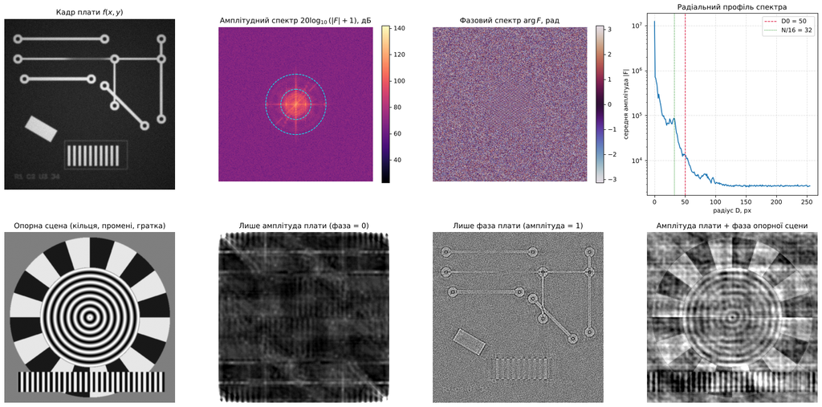

```python
# --- роль фази: амплітуда однієї сцени + фаза іншої
yy2, xx2 = np.mgrid[0:N, 0:N]
r2 = np.hypot(xx2 - N / 2, yy2 - N / 2); ang2 = np.arctan2(yy2 - N / 2, xx2 - N / 2)
ref = 128 + 70 * np.sin(2 * np.pi * r2 / 20) * (r2 < 150) + 55 * np.sign(np.sin(10 * ang2)) * ((r2 >= 150) & (r2 < 240))
ref[420:480, 40:480] = 128 + 60 * np.sign(np.sin(2 * np.pi * np.arange(40, 480) / 16))[None, :]
ref = ndimage.gaussian_filter(ref, 0.8)
F2 = np.fft.fft2(ref)
a1, p1, a2, p2 = np.abs(F), np.angle(F), np.abs(F2), np.angle(F2)
rec_a_only = np.real(np.fft.ifft2(a1))                     # лише амплітуда (фаза = 0)
rec_p_only = np.real(np.fft.ifft2(np.exp(1j * p1)))        # лише фаза (амплітуда = 1)
rec_a1p2 = np.real(np.fft.ifft2(a1 * np.exp(1j * p2)))     # амплітуда плати + фаза опорної сцени
rec_a2p1 = np.real(np.fft.ifft2(a2 * np.exp(1j * p1)))     # амплітуда опорної + фаза плати
corr = lambda a, b: float(np.corrcoef(a.ravel(), b.ravel())[0, 1])
print("=" * 96)
print("РОЛЬ ФАЗИ: кореляція реконструкцій із сценами (коефіцієнт Пірсона)")
print("=" * 96)
print(f"{'Реконструкція':<48}{'з платою':>12}{'з опорною сценою':>20}")
for nm, r_ in [("лише амплітуда плати (фаза = 0)", rec_a_only), ("лише фаза плати (амплітуда = 1)", rec_p_only),
               ("амплітуда плати + фаза опорної сцени", rec_a1p2), ("амплітуда опорної сцени + фаза плати", rec_a2p1)]:
    print(f"{nm:<48}{corr(r_, img):12.3f}{corr(r_, ref):20.3f}")
print("=" * 96)

fig, axes = plt.subplots(2, 4, figsize=(19, 9.6))
axes[0, 0].imshow(gray, cmap='gray'); axes[0, 0].set_title("Кадр плати $f(x,y)$")
im = axes[0, 1].imshow(S_db, cmap='magma'); axes[0, 1].set_title("Амплітудний спектр $20\\log_{10}(|F|+1)$, дБ"); plt.colorbar(im, ax=axes[0, 1], fraction=0.046)
for r_ in (50, 100): axes[0, 1].add_patch(plt.Circle((N // 2, N // 2), r_, fill=False, ec='cyan', lw=1, ls='--'))
im = axes[0, 2].imshow(phase, cmap='twilight', vmin=-np.pi, vmax=np.pi); axes[0, 2].set_title("Фазовий спектр $\\arg F$, рад"); plt.colorbar(im, ax=axes[0, 2], fraction=0.046)
axes[0, 3].semilogy(radii, rad_profile, color='#1f77b4', lw=1.5); axes[0, 3].axvline(50, color='crimson', ls='--', lw=1, label="D0 = 50"); axes[0, 3].axvline(32, color='green', ls=':', lw=1, label="N/16 = 32")
axes[0, 3].set_xlabel("радіус D, px"); axes[0, 3].set_ylabel("середня амплітуда |F|"); axes[0, 3].set_title("Радіальний профіль спектра"); axes[0, 3].legend(); axes[0, 3].grid(True)
axes[1, 0].imshow(ref, cmap='gray'); axes[1, 0].set_title("Опорна сцена (кільця, промені, гратка)")
axes[1, 1].imshow(rec_a_only, cmap='gray', vmin=np.percentile(rec_a_only, 1), vmax=np.percentile(rec_a_only, 99.5)); axes[1, 1].set_title("Лише амплітуда плати (фаза = 0)")
axes[1, 2].imshow(rec_p_only, cmap='gray', vmin=np.percentile(rec_p_only, 1), vmax=np.percentile(rec_p_only, 99)); axes[1, 2].set_title("Лише фаза плати (амплітуда = 1)")
axes[1, 3].imshow(rec_a1p2, cmap='gray', vmin=np.percentile(rec_a1p2, 1), vmax=np.percentile(rec_a1p2, 99)); axes[1, 3].set_title("Амплітуда плати + фаза опорної сцени")
for a in list(axes[0, :3]) + list(axes[1, :]): a.axis('off')
plt.tight_layout(); plt.savefig("figures/pcb_fft2d_spectrum_analysis.png", dpi=200); plt.show()
```

## 6. Частотна фільтрація: ILPF, GLPF, GHPF та ефект Гіббса

Фільтри задаються на центрованій сітці $D(u,v)$ і застосовуються як $g=\mathcal F^{-1}\{\mathrm{ifftshift}(H)\cdot F\}$ (обчислення ідуть із `float64`, без проміжного округлення). Перевіряються: (1) теорема згортки — гаусів фільтр збігається з гаусовим розмиттям у просторі, $\sigma_x=N/(2\pi\sigma_f)$; (2) фільтри комплементарні, $\mathrm{LP}+\mathrm{HP}=f$; (3) підсилення шуму $\sqrt{\sum H^2/N^2}$ для білого шуму; (4) ефект Гіббса на чистому ступінчастому краї (перерегулювання та період пульсацій проти теорії $8.95$ % і $N/D_0$); (5) циклічність ДПФ-фільтрації та артефакти на краях кадру.

```python
D0, SIGF = 50, 35.0
SIGMA_X = N / (2 * np.pi * SIGF)
H_ilpf = (Dm <= D0).astype(np.float64)
H_glpf = np.exp(-Dm ** 2 / (2 * SIGF ** 2))
H_ghpf = 1.0 - H_glpf

def apply_filter(a, Hc):
    out = np.fft.ifft2(np.fft.ifftshift(Hc) * np.fft.fft2(a))
    return np.real(out), float(np.abs(out.imag).max())

g_ilpf, im_i = apply_filter(img, H_ilpf)
g_glpf, im_g = apply_filter(img, H_glpf)
g_ghpf, im_h = apply_filter(img, H_ghpf)

# (1) теорема згортки: GLPF == циклічне гаусове розмиття
g_blur_wrap = ndimage.gaussian_filter(img, SIGMA_X, mode='wrap', truncate=6.0)
d_conv = np.abs(g_glpf - g_blur_wrap)
# (2) комплементарність
comp_err = float(np.abs(g_glpf + g_ghpf - img).max())
# (3) підсилення шуму: теорія sqrt(sum H^2 / N^2) та вимірювання
gain_th = {nm: float(np.sqrt((H ** 2).sum() / N ** 2)) for nm, H in [("ILPF", H_ilpf), ("GLPF", H_glpf), ("GHPF", H_ghpf)]}
noise_meas = {}
for nm, H in [("ILPF", H_ilpf), ("GLPF", H_glpf), ("GHPF", H_ghpf)]:
    nz, _ = apply_filter(noise, H)
    noise_meas[nm] = float(nz.std() / noise.std())

# (4) ефект Гіббса на чистому ступінчастому краї (без попереднього розмиття), стрибок 160 рівнів
STEP = 160.0
step = np.zeros((N, N)); step[:, 128:384] = STEP
prof = {"ILPF": apply_filter(step, H_ilpf)[0][N // 2], "GLPF": apply_filter(step, H_glpf)[0][N // 2]}
x_ax = np.arange(N)
def overshoot_pct(p):
    return float((p[128:384].max() - STEP) / STEP * 100), float(-p[0:128].min() / STEP * 100)
ov_i, un_i = overshoot_pct(prof["ILPF"]); ov_g, un_g = overshoot_pct(prof["GLPF"])
pk, _ = signal.find_peaks(prof["ILPF"][40:128])           # максимуми пульсацій ліворуч від краю
ripple_period = float(np.mean(np.diff(pk))) if len(pk) > 2 else float('nan')
def width_10_90(p, lo=100, hi=160):
    seg = p[lo:hi] / STEP
    i10 = np.where(seg >= 0.1)[0][0]; i90 = np.where(seg >= 0.9)[0][0]
    x10 = lo + i10 - 1 + (0.1 - seg[i10 - 1]) / (seg[i10] - seg[i10 - 1]); x90 = lo + i90 - 1 + (0.9 - seg[i90 - 1]) / (seg[i90] - seg[i90 - 1])
    return float(x90 - x10)
w_i, w_g = width_10_90(prof["ILPF"]), width_10_90(prof["GLPF"])
monotone_g = bool(np.all(np.diff(prof["GLPF"][100:156]) >= -1e-9))

# (5) циклічність: FFT-фільтр проти відбитого країв
g_blur_ref = ndimage.gaussian_filter(img, SIGMA_X, mode='reflect', truncate=6.0)
band = np.zeros((N, N), bool); band[:12, :] = band[-12:, :] = band[:, :12] = band[:, -12:] = True
border_diff = float(np.abs(g_glpf - g_blur_ref)[band].mean()); inner_diff = float(np.abs(g_glpf - g_blur_ref)[~band].mean())

# вплив на гратку виводів мікросхеми (поле 190..357 x 380..440)
pins = (slice(385, 435), slice(190, 358))
ac = lambda a: float(a[pins].std())
pin_ratio = {nm: ac(g) / ac(g_nf) for nm, g in [("ILPF", apply_filter(g_nf, H_ilpf)[0]), ("GLPF", apply_filter(g_nf, H_glpf)[0])]}
H_at_32 = {"ILPF": float(H_ilpf[N // 2, N // 2 + 32]), "GLPF": float(H_glpf[N // 2, N // 2 + 32])}
FF = np.fft.fft2(g_nf)
meas_gain_32 = {nm: float(np.abs(np.fft.fft2(apply_filter(g_nf, H)[0])[0, 32]) / np.abs(FF[0, 32])) for nm, H in [("ILPF", H_ilpf), ("GLPF", H_glpf)]}
passband = {nm: float(((H ** 2) * (np.abs(np.fft.fftshift(F)) ** 2)).sum() / (np.abs(F) ** 2).sum() * 100) for nm, H in [("ILPF", H_ilpf), ("GLPF", H_glpf), ("GHPF", H_ghpf)]}

print("=" * 100)
print(f"ЧАСТОТНА ФІЛЬТРАЦІЯ (D0 = {D0}, sigma_f = {SIGF}; еквівалентна просторова sigma_x = {SIGMA_X:.3f} px)")
print("=" * 100)
print(f"Уявна частина результату: ILPF {im_i:.1e}, GLPF {im_g:.1e}, GHPF {im_h:.1e} (фільтри симетричні -> результат дійсний)")
print(f"Теорема згортки: GLPF проти gaussian_filter(sigma_x, mode='wrap'): макс. різниця {d_conv.max():.3f}, середня {d_conv.mean():.4f} рівня")
print(f"Комплементарність GLPF + GHPF = f: макс. похибка {comp_err:.1e}")
print(f"{'Фільтр':<8}{'Підсилення шуму (теорія)':>28}{'виміряне':>12}{'Частка енергії кадру в смузі пропускання, %':>48}")
for nm in ("ILPF", "GLPF", "GHPF"): print(f"{nm:<8}{gain_th[nm]:28.4f}{noise_meas[nm]:12.4f}{passband[nm]:48.2f}")
print("-" * 100)
print(f"Ступінчастий край ({STEP:.0f} рівнів): ILPF — перерегулювання {ov_i:.2f} %, недорегулювання {un_i:.2f} % (теорія 8.95 %), період пульсацій {ripple_period:.2f} px (теорія N/D0 = {N / D0:.2f}); ширина краю 10-90 %: {w_i:.2f} px")
print(f"                        GLPF — перерегулювання {ov_g:.2f} %, профіль монотонний: {monotone_g}; ширина краю 10-90 %: {w_g:.2f} px (теорія 2.563 sigma_x = {2.563 * SIGMA_X:.2f} px)")
print(f"Циклічність ДПФ-фільтрації: середня різниця з фільтром із відбиттям країв — {border_diff:.3f} (смуга 12 px по краях) проти {inner_diff:.4f} усередині")
print(f"Гратка виводів (32 цикли/кадр): коефіцієнт пропускання H(32,0): ILPF {H_at_32['ILPF']:.3f}, GLPF {H_at_32['GLPF']:.3f}; виміряне підсилення компоненти: ILPF {meas_gain_32['ILPF']:.3f}, GLPF {meas_gain_32['GLPF']:.3f}")
print(f"Розмах (стандартне відхилення) яскравості на ділянці виводів після фільтра відносно початкового: ILPF {pin_ratio['ILPF']:.3f}, GLPF {pin_ratio['GLPF']:.3f}")
print("=" * 100)
```

```
====================================================================================================
ЧАСТОТНА ФІЛЬТРАЦІЯ (D0 = 50, sigma_f = 35.0; еквівалентна просторова sigma_x = 2.328 px)
====================================================================================================
Уявна частина результату: ILPF 4.0e-14, GLPF 3.2e-14, GHPF 4.4e-14 (фільтри симетричні -> результат дійсний)
Теорема згортки: GLPF проти gaussian_filter(sigma_x, mode='wrap'): макс. різниця 0.000, середня 0.0000 рівня
Комплементарність GLPF + GHPF = f: макс. похибка 1.1e-13
Фільтр      Підсилення шуму (теорія)    виміряне     Частка енергії кадру в смузі пропускання, %
ILPF                          0.1730      0.1729                                           98.57
GLPF                          0.1212      0.1217                                           91.55
GHPF                          0.9777      0.9777                                            2.45
----------------------------------------------------------------------------------------------------
Ступінчастий край (160 рівнів): ILPF — перерегулювання 8.83 %, недорегулювання 8.83 % (теорія 8.95 %), період пульсацій 10.14 px (теорія N/D0 = 10.24); ширина краю 10-90 %: 4.59 px
                        GLPF — перерегулювання 0.00 %, профіль монотонний: True; ширина краю 10-90 %: 6.06 px (теорія 2.563 sigma_x = 5.97 px)
Циклічність ДПФ-фільтрації: середня різниця з фільтром із відбиттям країв — 0.109 (смуга 12 px по краях) проти 0.0000 усередині
Гратка виводів (32 цикли/кадр): коефіцієнт пропускання H(32,0): ILPF 1.000, GLPF 0.658; виміряне підсилення компоненти: ILPF 1.000, GLPF 0.658
Розмах (стандартне відхилення) яскравості на ділянці виводів після фільтра відносно початкового: ILPF 1.002, GLPF 0.702
====================================================================================================
```

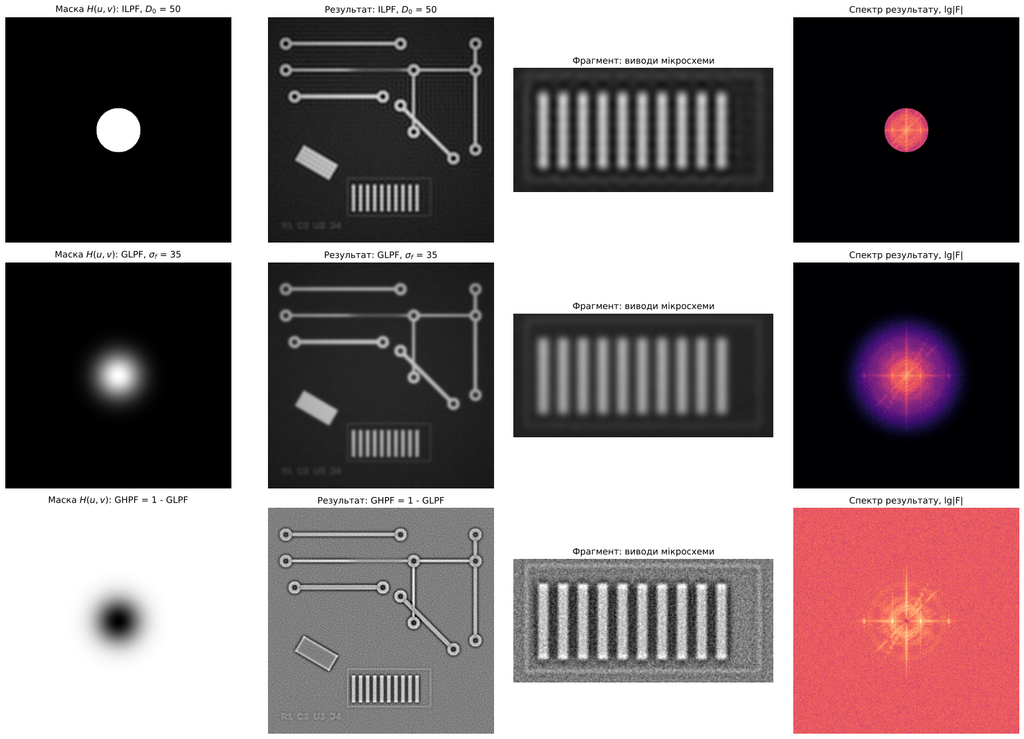

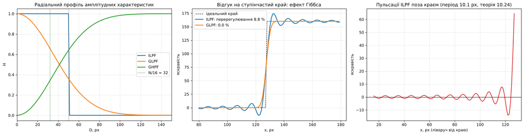

```python
fig, axes = plt.subplots(3, 4, figsize=(20, 14))
zoom = (slice(360, 460), slice(170, 380))
rows = [("ILPF, $D_0$ = 50", H_ilpf, g_ilpf), ("GLPF, $\\sigma_f$ = 35", H_glpf, g_glpf), ("GHPF = 1 - GLPF", H_ghpf, g_ghpf)]
for i, (nm, H, g) in enumerate(rows):
    axes[i, 0].imshow(H, cmap='gray', vmin=0, vmax=1); axes[i, 0].set_title(f"Маска $H(u,v)$: {nm}")
    if i < 2:
        axes[i, 1].imshow(np.clip(g, 0, 255), cmap='gray', vmin=0, vmax=255); axes[i, 2].imshow(np.clip(g[zoom], 0, 255), cmap='gray', vmin=0, vmax=255)
    else:
        axes[i, 1].imshow(g, cmap='gray', vmin=-40, vmax=40); axes[i, 2].imshow(g[zoom], cmap='gray', vmin=-40, vmax=40)
    axes[i, 1].set_title(f"Результат: {nm}"); axes[i, 2].set_title("Фрагмент: виводи мікросхеми")
    axes[i, 3].imshow(np.log10(np.abs(np.fft.fftshift(np.fft.fft2(g))) + 1), cmap='magma'); axes[i, 3].set_title("Спектр результату, lg|F|")
    for a in axes[i]: a.axis('off')
plt.tight_layout(); plt.savefig("figures/pcb_frequency_filtering_results.png", dpi=200); plt.show()

fig, axes = plt.subplots(1, 3, figsize=(19, 5))
axes[0].plot(np.arange(N // 2), H_ilpf[N // 2, N // 2:], label="ILPF", lw=2); axes[0].plot(np.arange(N // 2), H_glpf[N // 2, N // 2:], label="GLPF", lw=2); axes[0].plot(np.arange(N // 2), H_ghpf[N // 2, N // 2:], label="GHPF", lw=2)
axes[0].axvline(D0, color='gray', ls='--', lw=1); axes[0].axvline(32, color='green', ls=':', lw=1.2, label="N/16 = 32"); axes[0].set_xlim(0, 150)
axes[0].set_xlabel("D, px"); axes[0].set_ylabel("H"); axes[0].set_title("Радіальний профіль амплітудних характеристик"); axes[0].legend(); axes[0].grid(True)
axes[1].plot(x_ax[80:180], step[N // 2, 80:180], 'k--', lw=1, label="ідеальний край")
axes[1].plot(x_ax[80:180], prof["ILPF"][80:180], lw=2, label=f"ILPF: перерегулювання {ov_i:.1f} %"); axes[1].plot(x_ax[80:180], prof["GLPF"][80:180], lw=2, label=f"GLPF: {ov_g:.1f} %")
axes[1].set_xlabel("x, px"); axes[1].set_ylabel("яскравість"); axes[1].set_title("Відгук на ступінчастий край: ефект Гіббса"); axes[1].legend(); axes[1].grid(True)
x_r = np.arange(16, 128); axes[2].plot(x_r, prof["ILPF"][16:128], lw=1.6, color='#d62728'); axes[2].axhline(0, color='k', lw=0.8)
axes[2].set_xlabel("x, px (ліворуч від краю)"); axes[2].set_ylabel("яскравість"); axes[2].set_title(f"Пульсації ILPF поза краєм (період {ripple_period:.1f} px, теорія {N / D0:.2f})"); axes[2].grid(True)
plt.tight_layout(); plt.savefig("figures/pcb_gibbs_step_response.png", dpi=200); plt.show()
```

## 7. Градієнтні оператори Собеля та Шарра

Градієнти обчислюються `cv2.Sobel` та `cv2.Scharr` у `CV_64F` для кадру, попередньо згладженого гаусом ($\sigma=1$), і звіряються з прямою кореляцією ядер у `scipy.ndimage`. Для чесного порівняння відгуки нормуються на коефіцієнт підсилення рампи (8 та 32). Ізотропність оцінюється на аналітичному ступінчастому краї $160\,\Phi(d/\sigma)$ під кутами $0\ldots90^\circ$ (крок $1^\circ$): похибка кута градієнта та розкид пікової величини. Також перевіряється підсилення шуму: $\sqrt{\sum k_{ij}^2}/g$ ($g=8$ та $32$) — теорія $0.433\,\sigma_n$ і $0.480\,\sigma_n$.

```python
blur_u8 = cv2.GaussianBlur(gray, (5, 5), 1.0)
bl = blur_u8.astype(np.float64)
K_SOBEL = 3
ker_sx = np.array([[-1, 0, 1], [-2, 0, 2], [-1, 0, 1]], float); ker_sy = ker_sx.T
ker_cx = np.array([[-3, 0, 3], [-10, 0, 10], [-3, 0, 3]], float); ker_cy = ker_cx.T
sx = cv2.Sobel(bl, cv2.CV_64F, 1, 0, ksize=K_SOBEL); sy = cv2.Sobel(bl, cv2.CV_64F, 0, 1, ksize=K_SOBEL)
cx = cv2.Scharr(bl, cv2.CV_64F, 1, 0); cy = cv2.Scharr(bl, cv2.CV_64F, 0, 1)
chk_s = max(np.abs(sx - ndimage.correlate(bl, ker_sx, mode='mirror')).max(), np.abs(sy - ndimage.correlate(bl, ker_sy, mode='mirror')).max())
chk_c = max(np.abs(cx - ndimage.correlate(bl, ker_cx, mode='mirror')).max(), np.abs(cy - ndimage.correlate(bl, ker_cy, mode='mirror')).max())
gain = {"Собель": 8.0, "Шарр": 32.0}
mag_s_l2 = np.hypot(sx, sy) / 8; mag_c_l2 = np.hypot(cx, cy) / 32
mag_s_l1 = (np.abs(sx) + np.abs(sy)); mag_c_l1 = (np.abs(cx) + np.abs(cy))
ang_s = np.degrees(np.arctan2(sy, sx)); ang_c = np.degrees(np.arctan2(cy, cx))

# підсилення шуму
noise_s = np.hypot(ndimage.correlate(noise, ker_sx, mode='mirror'), ndimage.correlate(noise, ker_sy, mode='mirror'))
nx_s = ndimage.correlate(noise, ker_sx, mode='mirror').std() / 8 / SIGMA_N; nx_c = ndimage.correlate(noise, ker_cx, mode='mirror').std() / 32 / SIGMA_N
th_s = np.sqrt((ker_sx ** 2).sum()) / 8; th_c = np.sqrt((ker_cx ** 2).sum()) / 32

# ізотропність на аналітичному ступінчастому краї
def edge_image(theta_deg, sigma=1.0, n=129, amp_=160.0):
    yy_, xx_ = np.mgrid[0:n, 0:n] - n // 2
    th = np.deg2rad(theta_deg); d = xx_ * np.cos(th) + yy_ * np.sin(th)
    return amp_ * ndtr(d / sigma), th, d
thetas = np.arange(0, 91, 1.0)
err_s, err_c, pk_s, pk_c = [], [], [], []
for t in thetas:
    e, th, d = edge_image(t)
    near = (np.abs(d) < 1.5); near[:8, :] = near[-8:, :] = near[:, :8] = near[:, -8:] = False
    for (kx, ky, store_e, store_p, g_) in [(ker_sx, ker_sy, err_s, pk_s, 8.0), (ker_cx, ker_cy, err_c, pk_c, 32.0)]:
        gx_ = ndimage.correlate(e, kx, mode='mirror'); gy_ = ndimage.correlate(e, ky, mode='mirror')
        da = np.degrees(np.arctan2(gy_, gx_)) - t; da = (da + 180) % 360 - 180
        store_e.append(np.abs(da[near]).max()); store_p.append(np.hypot(gx_, gy_)[near].max() / g_)
err_s, err_c, pk_s, pk_c = map(np.array, (err_s, err_c, pk_s, pk_c))
rms_s, rms_c = float(np.sqrt((err_s ** 2).mean())), float(np.sqrt((err_c ** 2).mean()))
peak_true = 160.0 / (1.0 * np.sqrt(2 * np.pi))

# оцінка порогування градієнта (без NMS): еквівалентні пороги, T_sobel, T_scharr = 4 T_sobel (різниця підсилення 32/8)
def evaluate_edges(edge, tol=2.0):
    e = (edge > 0) & valid
    near_gt = dt_gt <= tol; near_silk = dt_silk <= tol
    tp = e & near_gt; silk_ = e & ~near_gt & near_silk; spur = e & ~near_gt & ~near_silk
    dt_e = cv2.distanceTransform((~e).astype(np.uint8), cv2.DIST_L2, 5)
    covered = (dt_e <= tol)
    g_all = gt & valid; g_dim = gt_dim & valid
    rec = float((g_all & covered).sum() / g_all.sum()); rec_dim = float((g_dim & covered).sum() / g_dim.sum())
    n = int(e.sum()); prec = float(tp.sum() / max(n, 1)); prec_ns = float(tp.sum() / max(tp.sum() + spur.sum(), 1))
    f1 = 2 * prec * rec / max(prec + rec, 1e-12)
    ncomp = int(cv2.connectedComponents(e.astype(np.uint8), connectivity=8)[0] - 1)
    return dict(n=n, tp=int(tp.sum()), silk=int(silk_.sum()), spur=int(spur.sum()), prec=prec, prec_no_silk=prec_ns, rec=rec, rec_dim=rec_dim, f1=f1, ncomp=ncomp,
                px_per_gt=float((e & near_gt).sum() / g_all.sum()), loc_err=float(dt_gt[tp].mean()) if tp.any() else float('nan'))

sweep_thr = np.arange(20, 800, 10)
best = {}
for nm, mag, scale in [("Собель", mag_s_l1, 1.0), ("Шарр", mag_c_l1, 4.0)]:
    f1s = [evaluate_edges(mag > t * scale)['f1'] for t in sweep_thr]
    i = int(np.argmax(f1s)); best[nm] = (float(sweep_thr[i]), float(f1s[i]))
ev_fix = {nm: evaluate_edges(mag > T * sc) for nm, mag, sc, T in [("Собель", mag_s_l1, 1.0, 180), ("Шарр", mag_c_l1, 4.0, 180)]}
ev_best = {nm: evaluate_edges(mag > best[nm][0] * sc) for nm, mag, sc in [("Собель", mag_s_l1, 1.0), ("Шарр", mag_c_l1, 4.0)]}

print("=" * 100)
print("ГРАДІЄНТНІ ОПЕРАТОРИ")
print("=" * 100)
print(f"cv2.Sobel(ksize=3) проти ndimage.correlate: макс. різниця {chk_s:.1e}; cv2.Scharr проти ndimage.correlate: {chk_c:.1e}")
print(f"Підсилення шуму (std градієнта / sigma_n): Собель — виміряно {nx_s:.4f}, теорія {th_s:.4f}; Шарр — виміряно {nx_c:.4f}, теорія {th_c:.4f}")
print(f"Аналітичний край (sigma = 1, стрибок 160, пік градієнта сигналу {peak_true:.1f} рівнів/px): похибка кута градієнта на крайових пікселях, градуси")
print(f"{'':<8}{'макс.':>9}{'СКВ за кутами':>16}{'пік. величина min':>20}{'max':>8}{'max/min':>10}")
print(f"{'Собель':<8}{err_s.max():9.2f}{rms_s:16.2f}{pk_s.min():20.2f}{pk_s.max():8.2f}{pk_s.max() / pk_s.min():10.3f}")
print(f"{'Шарр':<8}{err_c.max():9.2f}{rms_c:16.2f}{pk_c.min():20.2f}{pk_c.max():8.2f}{pk_c.max() / pk_c.min():10.3f}")
print(f"Кут із максимальною похибкою: Собель {thetas[np.argmax(err_s)]:.0f} градусів, Шарр {thetas[np.argmax(err_c)]:.0f} градусів")
print("-" * 100)
print(f"{'Порогування |Gx|+|Gy| без NMS':<34}{'поріг':>7}{'пікселів':>10}{'P (ціль)':>10}{'recall':>8}{'F1':>7}{'px/еталон':>11}{'компонент':>11}")
for nm in ("Собель", "Шарр"):
    r = ev_fix[nm]; print(f"{nm + ' (T = 180, еквівалент)':<34}{180:7.0f}{r['n']:10d}{r['prec']:10.3f}{r['rec']:8.3f}{r['f1']:7.3f}{r['px_per_gt']:11.2f}{r['ncomp']:11d}")
for nm in ("Собель", "Шарр"):
    r = ev_best[nm]; print(f"{nm + ' (найкращий F1)':<34}{best[nm][0]:7.0f}{r['n']:10d}{r['prec']:10.3f}{r['rec']:8.3f}{r['f1']:7.3f}{r['px_per_gt']:11.2f}{r['ncomp']:11d}")
print("=" * 100)
```

```
====================================================================================================
ГРАДІЄНТНІ ОПЕРАТОРИ
====================================================================================================
cv2.Sobel(ksize=3) проти ndimage.correlate: макс. різниця 0.0e+00; cv2.Scharr проти ndimage.correlate: 0.0e+00
Підсилення шуму (std градієнта / sigma_n): Собель — виміряно 0.4331, теорія 0.4330; Шарр — виміряно 0.4798, теорія 0.4801
Аналітичний край (sigma = 1, стрибок 160, пік градієнта сигналу 63.8 рівнів/px): похибка кута градієнта на крайових пікселях, градуси
            макс.   СКВ за кутами   пік. величина min     max   max/min
Собель       0.91            0.64               53.28   54.62     1.025
Шарр         0.14            0.10               54.62   54.68     1.001
Кут із максимальною похибкою: Собель 23 градусів, Шарр 21 градусів
----------------------------------------------------------------------------------------------------
Порогування |Gx|+|Gy| без NMS       поріг  пікселів  P (ціль)  recall     F1  px/еталон  компонент
Собель (T = 180, еквівалент)          180     17276     0.966   0.957  0.961       3.26         29
Шарр (T = 180, еквівалент)            180     17361     0.966   0.957  0.961       3.28         29
Собель (найкращий F1)                 210     12585     0.975   0.950  0.963       2.40         50
Шарр (найкращий F1)                   210     12698     0.975   0.951  0.963       2.42         49
====================================================================================================
```

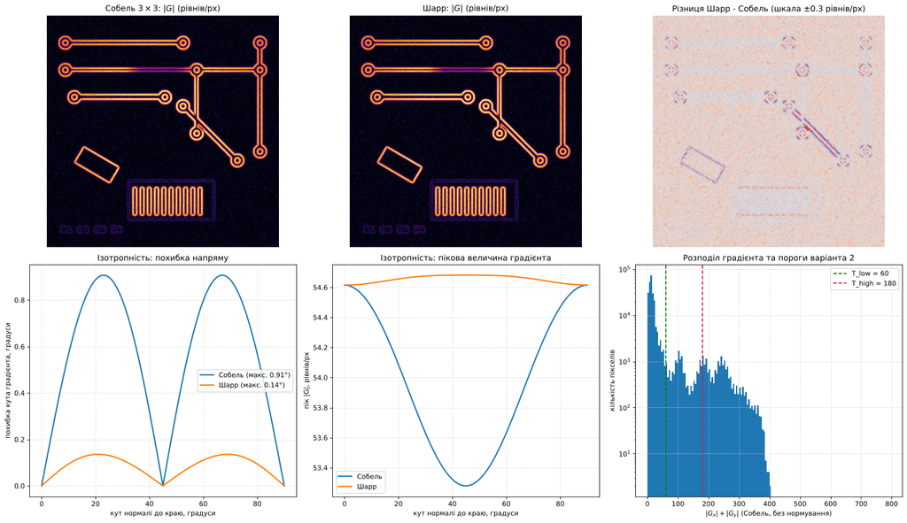

```python
fig, axes = plt.subplots(2, 3, figsize=(19, 11))
vmax_ = np.percentile(mag_s_l2, 99.8)
axes[0, 0].imshow(mag_s_l2, cmap='inferno', vmin=0, vmax=vmax_); axes[0, 0].set_title("Собель $3\\times3$: $|G|$ (рівнів/px)")
axes[0, 1].imshow(mag_c_l2, cmap='inferno', vmin=0, vmax=vmax_); axes[0, 1].set_title("Шарр: $|G|$ (рівнів/px)")
dd = mag_c_l2 - mag_s_l2; lim_ = np.percentile(np.abs(dd), 99.9); axes[0, 2].imshow(dd, cmap='coolwarm', vmin=-lim_, vmax=lim_); axes[0, 2].set_title(f"Різниця Шарр - Собель (шкала ±{lim_:.1f} рівнів/px)")
for a in axes[0]: a.axis('off')
axes[1, 0].plot(thetas, err_s, lw=2, label=f"Собель (макс. {err_s.max():.2f}°)"); axes[1, 0].plot(thetas, err_c, lw=2, label=f"Шарр (макс. {err_c.max():.2f}°)")
axes[1, 0].set_xlabel("кут нормалі до краю, градуси"); axes[1, 0].set_ylabel("похибка кута градієнта, градуси"); axes[1, 0].set_title("Ізотропність: похибка напряму"); axes[1, 0].legend(); axes[1, 0].grid(True)
axes[1, 1].plot(thetas, pk_s, lw=2, label="Собель"); axes[1, 1].plot(thetas, pk_c, lw=2, label="Шарр"); axes[1, 1].set_xlabel("кут нормалі до краю, градуси"); axes[1, 1].set_ylabel("пік |G|, рівнів/px")
axes[1, 1].set_title("Ізотропність: пікова величина градієнта"); axes[1, 1].legend(); axes[1, 1].grid(True)
axes[1, 2].hist(mag_s_l1.ravel(), bins=np.arange(0, 800, 5), color='#1f77b4', log=True)
for t_, c_, lb in [(60, 'green', 'T_low = 60'), (180, 'crimson', 'T_high = 180')]: axes[1, 2].axvline(t_, color=c_, ls='--', lw=1.5, label=lb)
axes[1, 2].set_xlabel("$|G_x|+|G_y|$ (Собель, без нормування)"); axes[1, 2].set_ylabel("кількість пікселів"); axes[1, 2].set_title("Розподіл градієнта та пороги варіанта 2"); axes[1, 2].legend(); axes[1, 2].grid(True)
plt.tight_layout(); plt.savefig("figures/pcb_sobel_scharr_gradients.png", dpi=200); plt.show()
```

## 8. Детектор Кенні та дослідження порогів гістерезису

Власна реалізація повторює алгоритм OpenCV: Собель $3\times3$ (`CV_16S`), модуль $|G_x|+|G_y|$, NMS за квантованим напрямом (горизонтальний при $|G_y|<|G_x|\tan22.5^\circ$, вертикальний при $|G_y|>|G_x|\tan67.5^\circ$, інакше діагональний за знаком $G_xG_y$), подвійний поріг (строге порівняння) і 8-зв'язний гістерезис через `scipy.ndimage.label`. Вона звіряється з `cv2.Canny` на тому ж згладженому кадрі. Досліджуються чотири режими порогів: варіант 2 $[60,180]$ та режими з методички $[30,80]$, $[50,150]$, $[120,220]$. Усі пікселі детектора розподіляються на: **TP** (поблизу еталонного контуру міді), **шовкографія** (справжні краї, але не ціль) і **хибні** (решта).

```python
def canny_stages(u8, low, high, ks=3):
    gx = cv2.Sobel(u8, cv2.CV_16S, 1, 0, ksize=ks, borderType=cv2.BORDER_REPLICATE).astype(np.int64)
    gy = cv2.Sobel(u8, cv2.CV_16S, 0, 1, ksize=ks, borderType=cv2.BORDER_REPLICATE).astype(np.int64)
    ax, ay = np.abs(gx), np.abs(gy); mag = ax + ay
    tg22 = int(0.4142135623730950488016887242097 * (1 << 15) + 0.5)
    horiz = (ay << 15) < ax * tg22
    vert = (ay << 15) > (ax * tg22 + (ax << 16))
    diag = ~horiz & ~vert
    P = np.pad(mag, 1)
    l, r_, u_, d_ = P[1:-1, :-2], P[1:-1, 2:], P[:-2, 1:-1], P[2:, 1:-1]
    ul, ur, dl, dr = P[:-2, :-2], P[:-2, 2:], P[2:, :-2], P[2:, 2:]
    s_pos = ~((gx < 0) != (gy < 0))
    p_ = np.where(s_pos, ul, ur); n_ = np.where(s_pos, dr, dl)
    nms = np.where(horiz, (mag > l) & (mag >= r_), np.where(vert, (mag > u_) & (mag >= d_), (mag > p_) & (mag > n_)))
    cand = nms & (mag > low); strong = nms & (mag > high)
    lab, n = ndimage.label(cand, structure=np.ones((3, 3)))
    keep = np.zeros(n + 1, bool); keep[np.unique(lab[strong])] = True; keep[0] = False
    edges = keep[lab]
    return dict(mag=mag, nms=nms, cand=cand, strong=strong, edges=edges, lab=lab, n_lab=n, gx=gx, gy=gy)

T_LOW, T_HIGH = 60, 180
MODES = [("Варіант 2: [60, 180]", 60, 180), ("М'який: [30, 80]", 30, 80), ("Середній: [50, 150]", 50, 150), ("Жорсткий: [120, 220]", 120, 220)]
fr = np.zeros((N, N), bool); fr[2:-2, 2:-2] = True      # порівняння всередині кадру (OpenCV по-іншому обробляє рамку)

print("=" * 100)
print("ПЕРЕВІРКА ВЛАСНОЇ РЕАЛІЗАЦІЇ КЕННІ ПРОТИ cv2.Canny (кадр після гаусового згладжування sigma = 1)")
print("=" * 100)
cmp_rows = []
for nm, lo, hi in MODES:
    mine = canny_stages(blur_u8, lo, hi)['edges'] & fr
    ref_ = (cv2.Canny(blur_u8, lo, hi, apertureSize=3, L2gradient=False) > 0) & fr
    jac = float((mine & ref_).sum() / max((mine | ref_).sum(), 1))
    cmp_rows.append((nm, int(mine.sum()), int(ref_.sum()), int((mine ^ ref_).sum()), jac))
    print(f"{nm:<24} власна: {mine.sum():6d} px   cv2.Canny: {ref_.sum():6d} px   різниця (XOR): {int((mine ^ ref_).sum()):5d} px   Жаккар: {jac:.5f}")

# властивість гістерезису: кожна збережена компонента містить сильний піксель; жодна відкинута його не містить
st = canny_stages(blur_u8, T_LOW, T_HIGH)
kept_labels = np.unique(st['lab'][st['edges']]); kept_labels = kept_labels[kept_labels > 0]
all_labels = np.arange(1, st['n_lab'] + 1)
has_strong = np.zeros(st['n_lab'] + 1, bool); has_strong[np.unique(st['lab'][st['strong']])] = True
hyst_ok = bool(all(has_strong[kept_labels]) and not any(has_strong[np.setdiff1d(all_labels, kept_labels)]))
n_weak_saved = int((st['edges'] & ~st['strong']).sum())
print("-" * 100)
print(f"Гістерезис [60, 180]: кандидатів (NMS і > T_low) {int(st['cand'].sum())} px у {st['n_lab']} компонентах; збережено {len(kept_labels)}; сильних пікселів {int(st['strong'].sum())}; слабких, збережених завдяки зв'язності: {n_weak_saved}; властивість гістерезису виконана: {hyst_ok}")

# розподіл величини градієнта на NMS-пікселях за класами
near_gt = dt_gt <= 2.0; near_silk = (dt_silk <= 2.0) & ~near_gt
nms_ = st['nms'] & fr
def pct(a): return np.percentile(a, [5, 50, 95]) if a.size else np.array([np.nan] * 3)
m_gt = st['mag'][nms_ & near_gt]; m_dim = st['mag'][nms_ & (dt_gt <= 2.0) & dim_roi]; m_silk = st['mag'][nms_ & near_silk]; m_bg = st['mag'][nms_ & ~near_gt & ~near_silk]
print(f"Величина |Gx|+|Gy| на NMS-пікселях (5-й / 50-й / 95-й перцентилі):")
for nm_, a in [("край міді (весь)", m_gt), ("край потьмянілої ділянки", m_dim), ("край шовкографії", m_silk), ("фон (шум, освітлення)", m_bg)]:
    p = pct(a); print(f"   {nm_:<28} n = {a.size:6d}:  {p[0]:7.1f} / {p[1]:7.1f} / {p[2]:7.1f}")
print("=" * 100)

edge_maps = {}; ev_modes = {}
for nm, lo, hi in MODES:
    e = cv2.Canny(blur_u8, lo, hi, apertureSize=3, L2gradient=False)
    edge_maps[nm] = e; ev_modes[nm] = evaluate_edges(e)
print("=" * 124)
print(f"ПОРІВНЯННЯ РЕЖИМІВ КЕННІ (допуск 2 px; вірні пікселі — біля еталонного контуру міді)")
print("=" * 124)
print(f"{'Режим':<24}{'пікселів':>9}{'TP':>7}{'шовкогр.':>10}{'хибні':>7}{'P (ціль)':>10}{'P (без шовк.)':>15}{'recall':>8}{'recall потьмян.':>17}{'F1':>7}{'компонент':>11}{'похибка, px':>13}")
for nm, lo, hi in MODES:
    r = ev_modes[nm]
    print(f"{nm:<24}{r['n']:9d}{r['tp']:7d}{r['silk']:10d}{r['spur']:7d}{r['prec']:10.3f}{r['prec_no_silk']:15.3f}{r['rec']:8.3f}{r['rec_dim']:17.3f}{r['f1']:7.3f}{r['ncomp']:11d}{r['loc_err']:13.3f}")
r1 = evaluate_edges(edge_maps[MODES[0][0]], tol=1.0)
print(f"Варіант 2 з допуском 1 px: P = {r1['prec']:.3f}, recall = {r1['rec']:.3f}, F1 = {r1['f1']:.3f}")
print("=" * 124)
```

```
====================================================================================================
ПЕРЕВІРКА ВЛАСНОЇ РЕАЛІЗАЦІЇ КЕННІ ПРОТИ cv2.Canny (кадр після гаусового згладжування sigma = 1)
====================================================================================================
Варіант 2: [60, 180]     власна:   5767 px   cv2.Canny:   5767 px   різниця (XOR):     0 px   Жаккар: 1.00000
М'який: [30, 80]         власна:   5843 px   cv2.Canny:   5843 px   різниця (XOR):     0 px   Жаккар: 1.00000
Середній: [50, 150]      власна:   5767 px   cv2.Canny:   5767 px   різниця (XOR):     0 px   Жаккар: 1.00000
Жорсткий: [120, 220]     власна:   5591 px   cv2.Canny:   5591 px   різниця (XOR):     0 px   Жаккар: 1.00000
----------------------------------------------------------------------------------------------------
Гістерезис [60, 180]: кандидатів (NMS і > T_low) 5931 px у 98 компонентах; збережено 26; сильних пікселів 5534; слабких, збережених завдяки зв'язності: 233; властивість гістерезису виконана: True
Величина |Gx|+|Gy| на NMS-пікселях (5-й / 50-й / 95-й перцентилі):
   край міді (весь)             n =   5769:    208.0 /   258.0 /   360.0
   край потьмянілої ділянки     n =    252:    102.0 /   116.0 /   190.9
   край шовкографії             n =   1755:     24.0 /    48.0 /    64.0
   фон (шум, освітлення)        n =  73472:      8.0 /    16.0 /    26.0
====================================================================================================
============================================================================================================================
ПОРІВНЯННЯ РЕЖИМІВ КЕННІ (допуск 2 px; вірні пікселі — біля еталонного контуру міді)
============================================================================================================================
Режим                    пікселів     TP  шовкогр.  хибні  P (ціль)  P (без шовк.)  recall  recall потьмян.     F1  компонент  похибка, px
Варіант 2: [60, 180]         5767   5767         0      0     1.000          1.000   1.000            1.000  1.000         26        0.502
М'який: [30, 80]             5843   5768        71      4     0.987          0.999   1.000            1.000  0.994         29        0.502
Середній: [50, 150]          5767   5767         0      0     1.000          1.000   1.000            1.000  1.000         26        0.502
Жорсткий: [120, 220]         5591   5591         0      0     1.000          1.000   0.967            0.325  0.983         27        0.502
Варіант 2 з допуском 1 px: P = 0.992, recall = 0.996, F1 = 0.994
============================================================================================================================
```

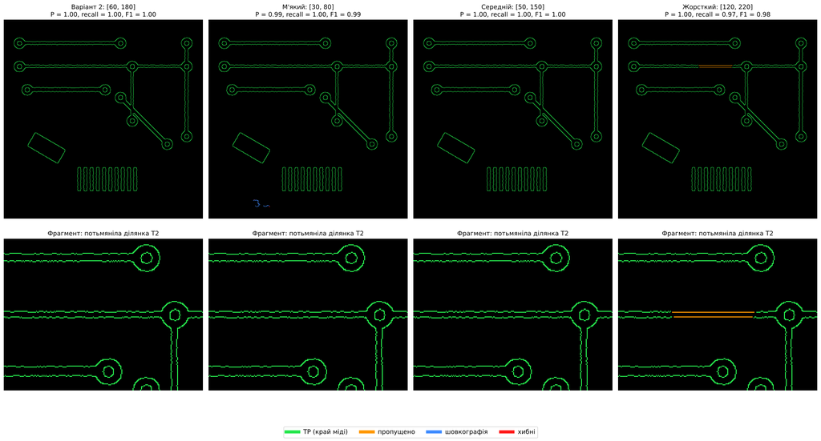

```python
def overlay(e, tol=2.0):
    e = (e > 0)
    rgb = np.zeros((N, N, 3), np.float32)
    dt_e = cv2.distanceTransform((~e).astype(np.uint8), cv2.DIST_L2, 5)
    rgb[gt & (dt_e > tol)] = (1.0, 0.6, 0.0)                                    # пропущені еталонні пікселі
    rgb[e & (dt_gt <= tol)] = (0.15, 0.9, 0.3)                                  # TP
    rgb[e & (dt_gt > tol) & (dt_silk <= tol)] = (0.25, 0.55, 1.0)               # шовкографія
    rgb[e & (dt_gt > tol) & (dt_silk > tol)] = (1.0, 0.1, 0.1)                  # хибні
    return rgb
roi = (slice(40, 200), slice(150, 360))
fig, axes = plt.subplots(2, 4, figsize=(22, 11.8))
for j, (nm, lo, hi) in enumerate(MODES):
    ov_ = overlay(edge_maps[nm]); r = ev_modes[nm]
    axes[0, j].imshow(ov_); axes[0, j].set_title(f"{nm}\nP = {r['prec']:.2f}, recall = {r['rec']:.2f}, F1 = {r['f1']:.2f}")
    axes[1, j].imshow(ov_[roi], interpolation='nearest'); axes[1, j].set_title("Фрагмент: потьмяніла ділянка T2")
    axes[0, j].axis('off'); axes[1, j].axis('off')
from matplotlib.lines import Line2D
leg = [Line2D([0], [0], color=c, lw=6, label=l) for c, l in [((0.15, 0.9, 0.3), "TP (край міді)"), ((1.0, 0.6, 0.0), "пропущено"), ((0.25, 0.55, 1.0), "шовкографія"), ((1.0, 0.1, 0.1), "хибні")]]
fig.legend(handles=leg, loc='lower center', ncol=4, fontsize=12)
plt.tight_layout(rect=(0, 0.03, 1, 1)); plt.savefig("figures/pcb_canny_thresholds_study.png", dpi=200); plt.show()
```

## 9. Вплив гістерезису, масштабу порога та попередньої фільтрації

Додатково досліджується: (а) **користь гістерезису** — той самий кадр із двома порогами порівнюється з порогуванням лише за $T_{high}$ та лише за $T_{low}$ після NMS; (б) **розгортка порога** $T_{high}\in[20,420]$ при зафіксованому співвідношенні $T_{low}=T_{high}/3$ (як у варіанті 2); (в) **попередня фільтрація** перед Кенні замість гаусового згладжування: без фільтра, ILPF ($D_0=50$) та GLPF ($\sigma_f=35$). Для (в) відфільтрований кадр округлюється до `uint8` та обробляється `cv2.Canny` із порогами варіанта 2: ILPF має породити хибні краї через кільця Гіббса.

```python
# (а) гістерезис проти одного порога
nms_all = st['nms']
e_hyst = st['edges']; e_high = nms_all & (st['mag'] > T_HIGH); e_low = nms_all & (st['mag'] > T_LOW)
ev_h = {"два пороги (гістерезис)": evaluate_edges(e_hyst), "лише T_high = 180": evaluate_edges(e_high), "лише T_low = 60": evaluate_edges(e_low)}

# (б) розгортка T_high зі співвідношенням 1:3
sweep_t = np.arange(20, 421, 10)
sweep = []
for th in sweep_t:
    e = cv2.Canny(blur_u8, th / 3.0, float(th), apertureSize=3, L2gradient=False)
    r = evaluate_edges(e); sweep.append((int(th), r['prec'], r['rec'], r['f1'], r['silk'], r['spur'], r['rec_dim']))
sweep = np.array(sweep)
i_best = int(np.argmax(sweep[:, 3]))

# (в) попередня фільтрація
pre = {}
pre["гаусів блюр sigma = 1 (основний)"] = blur_u8
pre["без фільтра"] = gray
pre["ILPF, D0 = 50"] = np.clip(np.round(apply_filter(img, H_ilpf)[0]), 0, 255).astype(np.uint8)
pre["GLPF, sigma_f = 35"] = np.clip(np.round(apply_filter(img, H_glpf)[0]), 0, 255).astype(np.uint8)
ev_pre, edge_pre = {}, {}
for nm, u8 in pre.items():
    e = cv2.Canny(u8, T_LOW, T_HIGH, apertureSize=3, L2gradient=False); edge_pre[nm] = e; ev_pre[nm] = evaluate_edges(e)

print("=" * 112)
print("(а) КОРИСТЬ ГІСТЕРЕЗИСУ (варіант 2, після NMS)")
print("=" * 112)
print(f"{'Схема':<28}{'пікселів':>9}{'P (ціль)':>10}{'recall':>8}{'recall потьмян.':>17}{'F1':>7}{'компонент':>11}")
for nm, r in ev_h.items(): print(f"{nm:<28}{r['n']:9d}{r['prec']:10.3f}{r['rec']:8.3f}{r['rec_dim']:17.3f}{r['f1']:7.3f}{r['ncomp']:11d}")
print("=" * 112)
print(f"(б) РОЗГОРТКА T_high (T_low = T_high / 3): найкраще F1 = {sweep[i_best, 3]:.3f} при T_high = {sweep[i_best, 0]:.0f} (P = {sweep[i_best, 1]:.3f}, recall = {sweep[i_best, 2]:.3f}); у точці варіанта 2 (T_high = 180): F1 = {sweep[sweep[:, 0] == 180][0, 3]:.3f}")
tab = [20, 40, 60, 80, 120, 180, 260, 340, 420]
print(f"{'T_high':>8}" + "".join(f"{int(t):>8d}" for t in tab))
for k_, nm_ in [(1, 'P'), (2, 'recall'), (3, 'F1'), (6, 'rec.потьм')]: print(f"{nm_:>8}" + "".join(f"{sweep[sweep[:, 0] == t][0, k_]:8.3f}" for t in tab))
print(f"{'шовкогр.':>8}" + "".join(f"{int(sweep[sweep[:, 0] == t][0, 4]):8d}" for t in tab)); print(f"{'хибні':>8}" + "".join(f"{int(sweep[sweep[:, 0] == t][0, 5]):8d}" for t in tab))
print("=" * 112)
print("(в) ПОПЕРЕДНЯ ФІЛЬТРАЦІЯ ПЕРЕД cv2.Canny [60, 180] (допуск 2 px)")
print("=" * 112)
print(f"{'Схема':<36}{'пікселів':>9}{'TP':>7}{'шовкогр.':>10}{'хибні':>7}{'P (ціль)':>10}{'recall':>8}{'recall потьм.':>15}{'F1':>7}")
for nm, r in ev_pre.items(): print(f"{nm:<36}{r['n']:9d}{r['tp']:7d}{r['silk']:10d}{r['spur']:7d}{r['prec']:10.3f}{r['rec']:8.3f}{r['rec_dim']:15.3f}{r['f1']:7.3f}")
print("=" * 112)
```

```
================================================================================================================
(а) КОРИСТЬ ГІСТЕРЕЗИСУ (варіант 2, після NMS)
================================================================================================================
Схема                        пікселів  P (ціль)  recall  recall потьмян.     F1  компонент
два пороги (гістерезис)          5767     1.000   1.000            1.000  1.000         26
лише T_high = 180                5534     1.000   0.957            0.119  0.978         30
лише T_low = 60                  5931     0.973   1.000            1.000  0.986         98
================================================================================================================
(б) РОЗГОРТКА T_high (T_low = T_high / 3): найкраще F1 = 1.000 при T_high = 90 (P = 1.000, recall = 1.000); у точці варіанта 2 (T_high = 180): F1 = 1.000
  T_high      20      40      60      80     120     180     260     340     420
       P   0.085   0.707   0.781   0.987   1.000   1.000   1.000   1.000   0.000
  recall   1.000   1.000   1.000   1.000   1.000   1.000   1.000   0.576   0.000
      F1   0.157   0.829   0.877   0.993   1.000   1.000   1.000   0.731   0.000
rec.потьм   1.000   1.000   1.000   1.000   1.000   1.000   1.000   0.179   0.000
шовкогр.    1720    1692    1514      71       0       0       0       0       0
   хибні   60398     696     106       7       0       0       0       0       0
================================================================================================================
(в) ПОПЕРЕДНЯ ФІЛЬТРАЦІЯ ПЕРЕД cv2.Canny [60, 180] (допуск 2 px)
================================================================================================================
Схема                                пікселів     TP  шовкогр.  хибні  P (ціль)  recall  recall потьм.     F1
гаусів блюр sigma = 1 (основний)         5767   5767         0      0     1.000   1.000          1.000  1.000
без фільтра                              5898   5890         0      8     0.999   1.000          1.000  0.999
ILPF, D0 = 50                            5664   5635         0     29     0.995   0.999          1.000  0.997
GLPF, sigma_f = 35                       5427   5427         0      0     1.000   0.942          0.659  0.970
================================================================================================================
```

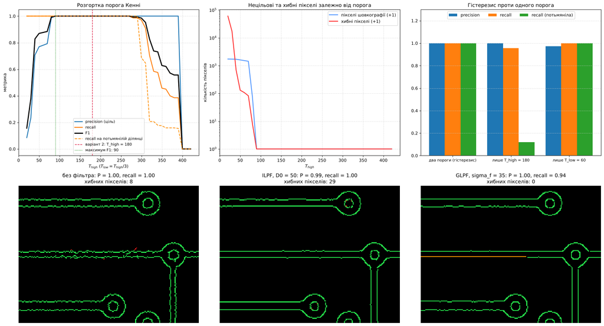

```python
fig, axes = plt.subplots(2, 3, figsize=(20, 11))
axes[0, 0].plot(sweep[:, 0], sweep[:, 1], lw=2, label="precision (ціль)"); axes[0, 0].plot(sweep[:, 0], sweep[:, 2], lw=2, label="recall"); axes[0, 0].plot(sweep[:, 0], sweep[:, 3], lw=2.5, color='k', label="F1")
axes[0, 0].plot(sweep[:, 0], sweep[:, 6], lw=1.6, ls='--', color='darkorange', label="recall на потьмянілій ділянці")
axes[0, 0].axvline(180, color='crimson', ls='--', lw=1.2, label="варіант 2: T_high = 180"); axes[0, 0].axvline(sweep[i_best, 0], color='green', ls=':', lw=1.2, label=f"максимум F1: {sweep[i_best, 0]:.0f}")
axes[0, 0].set_xlabel("$T_{high}$ ($T_{low}=T_{high}/3$)"); axes[0, 0].set_ylabel("метрика"); axes[0, 0].set_title("Розгортка порога Кенні"); axes[0, 0].legend(fontsize=9); axes[0, 0].grid(True)
axes[0, 1].semilogy(sweep[:, 0], sweep[:, 4] + 1, lw=2, color='#5599ff', label="пікселі шовкографії (+1)"); axes[0, 1].semilogy(sweep[:, 0], sweep[:, 5] + 1, lw=2, color='#ff3333', label="хибні пікселі (+1)")
axes[0, 1].set_xlabel("$T_{high}$"); axes[0, 1].set_ylabel("кількість пікселів"); axes[0, 1].set_title("Нецільові та хибні пікселі залежно від порога"); axes[0, 1].legend(); axes[0, 1].grid(True)
labs_h = list(ev_h.keys()); xs = np.arange(len(labs_h)); w_ = 0.27
axes[0, 2].bar(xs - w_, [ev_h[k]['prec'] for k in labs_h], w_, label="precision"); axes[0, 2].bar(xs, [ev_h[k]['rec'] for k in labs_h], w_, label="recall"); axes[0, 2].bar(xs + w_, [ev_h[k]['rec_dim'] for k in labs_h], w_, label="recall (потьмяніла)")
axes[0, 2].set_xticks(xs); axes[0, 2].set_xticklabels(labs_h, fontsize=9); axes[0, 2].set_ylim(0, 1.3); axes[0, 2].set_title("Гістерезис проти одного порога"); axes[0, 2].legend(ncol=3, loc='upper center'); axes[0, 2].grid(True, axis='y')
for j, nm in enumerate(["без фільтра", "ILPF, D0 = 50", "GLPF, sigma_f = 35"]):
    r = ev_pre[nm]; axes[1, j].imshow(overlay(edge_pre[nm])[40:200, 150:360], interpolation='nearest')
    axes[1, j].set_title(f"{nm}: P = {r['prec']:.2f}, recall = {r['rec']:.2f}\nхибних пікселів: {r['spur']}"); axes[1, j].axis('off')
plt.tight_layout(); plt.savefig("figures/pcb_canny_sweep_prefilter.png", dpi=200); plt.show()
```

## 10. Збереження результатів у `data/` та `figures/`

```python
def save_png(name, a):
    a = np.asarray(a)
    if a.dtype != np.uint8:
        lo, hi = float(a.min()), float(a.max()); a = np.clip((a - lo) / max(hi - lo, 1e-12) * 255, 0, 255).astype(np.uint8)
    cv2.imwrite(f"data/{name}", a)

save_png("pcb_gray.png", gray); save_png("pcb_copper_mask.png", mask); save_png("pcb_gt_boundary.png", gt.astype(np.uint8) * 255)
save_png("spectrum_log_amplitude.png", S_db); save_png("spectrum_phase.png", phase)
save_png("filtered_ilpf.png", np.clip(g_ilpf, 0, 255).astype(np.uint8)); save_png("filtered_glpf.png", np.clip(g_glpf, 0, 255).astype(np.uint8)); save_png("filtered_ghpf.png", g_ghpf)
save_png("sobel_magnitude.png", np.clip(mag_s_l2 / np.percentile(mag_s_l2, 99.8) * 255, 0, 255).astype(np.uint8)); save_png("scharr_magnitude.png", np.clip(mag_c_l2 / np.percentile(mag_s_l2, 99.8) * 255, 0, 255).astype(np.uint8))
for j, (nm, lo, hi) in enumerate(MODES):
    cv2.imwrite(f"data/canny_{lo}_{hi}.png", edge_maps[nm])

with open("data/canny_modes.csv", "w", newline="", encoding="utf-8") as f:
    w = csv.writer(f); w.writerow(["mode", "t_low", "t_high", "pixels", "tp", "silkscreen", "spurious", "precision_target", "precision_excl_silkscreen", "recall", "recall_dim_segment", "f1", "components", "mean_loc_err_px"])
    for nm, lo, hi in MODES:
        r = ev_modes[nm]; w.writerow([nm, lo, hi, r['n'], r['tp'], r['silk'], r['spur'], f"{r['prec']:.4f}", f"{r['prec_no_silk']:.4f}", f"{r['rec']:.4f}", f"{r['rec_dim']:.4f}", f"{r['f1']:.4f}", r['ncomp'], f"{r['loc_err']:.4f}"])
with open("data/canny_sweep.csv", "w", newline="", encoding="utf-8") as f:
    w = csv.writer(f); w.writerow(["t_high", "precision", "recall", "f1", "silkscreen_px", "spurious_px", "recall_dim_segment"])
    for row in sweep: w.writerow([int(row[0])] + [f"{v:.4f}" for v in row[1:4]] + [int(row[4]), int(row[5]), f"{row[6]:.4f}"])
with open("data/prefilter_study.csv", "w", newline="", encoding="utf-8") as f:
    w = csv.writer(f); w.writerow(["prefilter", "pixels", "tp", "silkscreen", "spurious", "precision", "recall", "recall_dim_segment", "f1"])
    for nm, r in ev_pre.items(): w.writerow([nm, r['n'], r['tp'], r['silk'], r['spur'], f"{r['prec']:.4f}", f"{r['rec']:.4f}", f"{r['rec_dim']:.4f}", f"{r['f1']:.4f}"])
with open("data/gradient_metrics.csv", "w", newline="", encoding="utf-8") as f:
    w = csv.writer(f); w.writerow(["operator", "max_angle_err_deg", "rms_angle_err_deg", "peak_ratio_max_min", "noise_gain_measured", "noise_gain_theory", "best_threshold", "best_f1"])
    w.writerow(["Sobel", f"{err_s.max():.3f}", f"{rms_s:.3f}", f"{pk_s.max() / pk_s.min():.4f}", f"{nx_s:.4f}", f"{th_s:.4f}", best["Собель"][0], f"{best['Собель'][1]:.4f}"])
    w.writerow(["Scharr", f"{err_c.max():.3f}", f"{rms_c:.3f}", f"{pk_c.max() / pk_c.min():.4f}", f"{nx_c:.4f}", f"{th_c:.4f}", best["Шарр"][0], f"{best['Шарр'][1]:.4f}"])

def clean(o):
    if isinstance(o, dict): return {k: clean(v) for k, v in o.items()}
    if isinstance(o, (list, tuple)): return [clean(v) for v in o]
    if isinstance(o, (np.floating, float)): return None if not np.isfinite(o) else float(o)
    if isinstance(o, np.integer): return int(o)
    if isinstance(o, np.bool_): return bool(o)
    return o
results = dict(
    variant=2, params=dict(N=N, D0=D0, sigma_f=SIGF, sigma_x=SIGMA_X, k_sobel=K_SOBEL, canny=[T_LOW, T_HIGH], seed=RNG_SEED),
    scene=dict(copper_px=int((mask > 0).sum()), gt_boundary_px=int(gt.sum()), silk_boundary_px=int(silk_b.sum()), dim_boundary_px=int(gt_dim.sum())),
    dft=dict(err_vs_numpy=float(err_dft), err_inverse=float(err_inv), parseval_rel=float(abs(parseval_lhs - parseval_rhs) / parseval_lhs), dc_pos=list(dc_pos), shift_amp_err=float(amp_shift_err),
             dynamic_range_db=float(dyn_range_db), energy_within={str(r): energy_within(r) for r in (10, 25, 35, 50, 75, 100, 150)}, pin_peak_prominence=prominence),
    phase_corr=dict(amp_only_vs_board=corr(rec_a_only, img), phase_only_vs_board=corr(rec_p_only, img), a1p2_vs_board=corr(rec_a1p2, img), a1p2_vs_ref=corr(rec_a1p2, ref), a2p1_vs_board=corr(rec_a2p1, img), a2p1_vs_ref=corr(rec_a2p1, ref)),
    filters=dict(conv_theorem_max=float(d_conv.max()), conv_theorem_mean=float(d_conv.mean()), complement_err=comp_err, noise_gain_theory=gain_th, noise_gain_measured=noise_meas, passband_energy_pct=passband,
                 gibbs=dict(ilpf_overshoot_pct=ov_i, ilpf_undershoot_pct=un_i, glpf_overshoot_pct=ov_g, ripple_period=ripple_period, ripple_period_theory=N / D0, width_ilpf=w_i, width_glpf=w_g, width_glpf_theory=2.563 * SIGMA_X, glpf_monotone=monotone_g),
                 border_diff=border_diff, inner_diff=inner_diff, pin_ratio=pin_ratio, H_at_32=H_at_32, meas_gain_32=meas_gain_32),
    gradients=dict(check_sobel=float(chk_s), check_scharr=float(chk_c), noise=dict(sobel=[float(nx_s), float(th_s)], scharr=[float(nx_c), float(th_c)]),
                   angle=dict(sobel_max=float(err_s.max()), sobel_rms=rms_s, scharr_max=float(err_c.max()), scharr_rms=rms_c), peak_ratio=dict(sobel=float(pk_s.max() / pk_s.min()), scharr=float(pk_c.max() / pk_c.min())),
                   fixed=ev_fix, best=dict(best), best_eval=ev_best),
    canny=dict(vs_opencv=[dict(mode=a, own=b, cv2=c, xor=d, jaccard=e) for a, b, c, d, e in cmp_rows], hysteresis_ok=hyst_ok, weak_saved=n_weak_saved, modes={nm: ev_modes[nm] for nm, _, _ in MODES},
               variant_tol1=r1, hysteresis_study=ev_h, sweep_best=dict(t_high=float(sweep[i_best, 0]), f1=float(sweep[i_best, 3]), precision=float(sweep[i_best, 1]), recall=float(sweep[i_best, 2])), prefilter=ev_pre,
               mag_percentiles=dict(copper=pct(m_gt).tolist(), dim=pct(m_dim).tolist(), silk=pct(m_silk).tolist(), background=pct(m_bg).tolist())))
with open("data/results.json", "w", encoding="utf-8") as f: json.dump(clean(results), f, ensure_ascii=False, indent=1)
print("Готово: figures/, data/")
```

```
Готово: figures/, data/
```

## Висновки

1. **Базова тестова сцена методички (блоки 1–5, скрипт `lab11_fft2d_edges.py`).** На сцені $512\times512$ (кола, повернутий прямокутник, штрихова решітка, промені, текст, слабоконтрастне кільце $+60$ рівнів) амплітудний спектр має максимум $143.4$ дБ у центрі $(256,256)$ (нульова частота після `fftshift`); рівність Парсеваля виконується точно, обернене ДПФ відновлює кадр із похибкою $1.1\cdot10^{-13}$. ILPF ($D_0=50$) дає кільця Гіббса: діапазон результату $[-155.6;\,226.5]$ при яскравості сцени $[11;\,217]$ (вихід за межі динамічного діапазону), GLPF ($\sigma_f=35$) лишається в діапазоні $[27.9;\,201.6]$ без кілець; PSNR відносно кадру без шуму $25.27$ дБ (ILPF) та $24.16$ дБ (GLPF), GHPF $=1-$GLPF дає діапазон $[-77.7;\,78.7]$, $\mathrm{GLPF}+\mathrm{GHPF}=f$ з похибкою $1.1\cdot10^{-13}$. Градієнти (`CV_64F`, $k=3$): Собель $\max|G|=455.6$, середнє $68.82$; Шарр $\max|G|=1859.9$, середнє $281.51$, відношення середніх $4.09$ при коефіцієнті підсилення рампи $32/8=4$. Детектор Кенні (допуск $2$ px до еталонного контуру з $11437$ px):

   | Режим $[T_{low},T_{high}]$ | пікселів | хибні | $P$ | recall | $F_1$ | |---|:-:|:-:|:-:|:-:|:-:| | варіант 2 $[60,180]$ | 12810 | 0 | $1.000$ | $0.949$ | $0.974$ | | $[30,80]$ | 13532 | 1 | $1.000$ | $0.999$ | $1.000$ | | $[50,150]$ | 13529 | 0 | $1.000$ | $0.999$ | $1.000$ | | $[120,220]$ | 12790 | 0 | $1.000$ | $0.948$ | $0.973$ |

   Режими $[60,180]$ і $[120,220]$ пропускають слабоконтрастне кільце (його краї мають градієнт нижчий за $T_{high}$), тому recall $\approx0.95$; режими $[30,80]$ і $[50,150]$ його знаходять. Контрастні елементи (кола, прямокутник, решітка, промені, текст) знаходяться в усіх режимах. Це узгоджується з результатами на платі (розділи 4–10): поріг $T_{high}$ має лежати нижче градієнта найслабших цільових країв.
2. **Двовимірне ДПФ та його властивості.** Власна реалізація $F=WfW$ збігається з `numpy.fft.fft2` (макс. відносна похибка $2.4\cdot10^{-14}$), обернене ДПФ відновлює кадр із похибкою $1.1\cdot10^{-13}$, рівність Парсеваля виконується з відносною різницею $1.3\cdot10^{-16}$, а $F(0,0)=\sum f$ точно. Нульова частота до `fftshift` лежить у куті $(0,0)$, після — у центрі $(256,256)$. Циклічний зсув кадру на $(37,-23)$ змінює амплітуду не більше ніж на $2.8\cdot10^{-17}$ відносно максимуму, а фаза змінюється за очікуваним лінійним законом. Амплітудний спектр плати має динамічний діапазон $73$ дБ ($4.6\cdot10^{3}$ разів між максимумом і медіаною): у лінійному масштабі лише $0.30$ % відліків перевищують $1$ % максимуму, тому для візуалізації потрібен логарифм. Енергія змінної складової зосереджена в низьких частотах: у колі $D\le10$ — $53.4$ %, $D\le35$ — $92.5$ %, $D\le50$ — $96.4$ %, $D\le150$ — $98.1$ %. Гратка виводів мікросхеми (період $16$ px) дає пік на частоті $N/16=32$ цикли/кадр, що перевищує медіану на цьому радіусі в $7.7$ раза.
3. **Роль амплітуди та фази.** Кадр лише з амплітудою плати (фаза $=0$) не містить структури: кореляція з платою $-0.029$. Кадр лише з фазою (амплітуда $=1$) уже показує контури доріжок і майданчиків (кореляція $0.241$). У змішаних реконструкціях структура йде за фазою: «амплітуда плати + фаза опорної сцени» корелює з опорною сценою на $0.570$ і з платою лише на $0.127$, а «амплітуда опорної сцени + фаза плати» — з платою на $0.570$ і з опорною сценою на $0.043$. Отже, положення країв закодоване переважно у фазі, а амплітуда визначає лише розподіл енергії за частотами.
4. **Частотні фільтри ILPF, GLPF, GHPF.** Гаусів фільтр із $\sigma_f=35$ збігається з просторовим гаусовим розмиттям $\sigma_x=N/(2\pi\sigma_f)=2.328$ px (`gaussian_filter`, `mode='wrap'`) з максимальною різницею менше $0.0005$ рівня, що підтверджує теорему згортки; $\mathrm{GLPF}+\mathrm{GHPF}=f$ з похибкою $1.1\cdot10^{-13}$. Підсилення білого шуму співпадає з теорією $\sqrt{\sum H^2/N^2}$: ILPF $0.1729$ (теорія $0.1730$), GLPF $0.1217$ ($0.1212$), GHPF $0.9777$ ($0.9777$). Частки енергії кадру у смузі пропускання: $98.6$ % (ILPF), $91.6$ % (GLPF), $2.5$ % (GHPF). Гратка виводів на $32$ циклах/кадр проходить через ILPF без змін ($H=1$, розмах яскравості $1.002$ від початкового), а через GLPF послаблюється до $H(32,0)=0.658$ (виміряне підсилення компоненти $0.658$, розмах $0.702$), тобто контраст виводів падає на $30$ %.
5. **Ефект Гіббса.** На чистому ступінчастому краї ($160$ рівнів) ILPF дає перерегулювання та недорегулювання $8.83$ % (теорія для ідеального обрізання $8.95$ %) та пульсації з періодом $10.14$ px (теорія $N/D_0=10.24$ px); ширина краю 10–90 % — $4.59$ px, тобто край різкіший, ніж після GLPF. GLPF не дає перерегулювання (профіль монотонний), але ширина краю $6.06$ px ($2.563\sigma_x=5.97$ px). На зображенні плати кільця ILPF видно поряд із контрастними краями. Фільтрація через ДПФ циклічна: у смузі $12$ px по краях кадру результат відрізняється від фільтра з відбиттям у середньому на $0.109$ рівня (усередині — $<0.0001$) через змішування протилежних країв кадру з різним освітленням.
6. **Градієнти Собеля та Шарра.** `cv2.Sobel` і `cv2.Scharr` збігаються з прямою кореляцією ядер у `scipy.ndimage` точно (різниця $0$). Підсилення шуму відповідає теорії $\sqrt{\sum k^2}/g$: Собель $0.4331\,\sigma_n$ ($0.4330$), Шарр $0.4798\,\sigma_n$ ($0.4801$), тобто Шарр шумить на $11$ % сильніше при тому ж нормуванні. Перевага Шарра — ізотропність: на аналітичному краї максимальна похибка напряму $0.14^\circ$ проти $0.91^\circ$ у Собеля (СКВ за кутами $0.10^\circ$ проти $0.64^\circ$), розкид пікового значення градієнта за кутами $0.1$ % проти $2.5$ %; обидва мають максимум похибки поблизу $22^\circ$ і нуль на $0^\circ$, $45^\circ$, $90^\circ$. Проте для виділення границь на цій платі різниця не відчутна: порогування $|G_x|+|G_y|$ при еквівалентних порогах ($180$ для Собеля, $720$ для Шарра) дає $F_1=0.961$ в обох. Порогування без NMS дає товсті контури: $17276$ px проти $5118$ еталонних ($3.3$ px на піксель еталона), навіть при найкращому порозі ($210$) — $2.4$ px і $F_1=0.963$.
7. **Детектор Кенні.** Власна реалізація (Собель, NMS за квантованим напрямом, подвійний поріг, 8-зв'язний гістерезис) збігається з `cv2.Canny` повністю: різниця $0$ px (коефіцієнт Жаккара $1.00000$) у всіх чотирьох режимах. Величина $|G_x|+|G_y|$ на NMS-пікселях (5-й / 50-й / 95-й перцентилі): край міді $208\,/\,258\,/\,360$; край потьмянілої ділянки $102\,/\,116\,/\,191$; шовкографія $24\,/\,48\,/\,64$; фон $8\,/\,16\,/\,26$. Режими порогів (допуск $2$ px, ціль — границі міді):

   | Режим $[T_{low},T_{high}]$ | пікселів | шовкографія | хибні | $P$ | recall | recall потьмянілої ділянки | $F_1$ | компонент | |---|:-:|:-:|:-:|:-:|:-:|:-:|:-:|:-:| | варіант 2 $[60,180]$ | 5767 | 0 | 0 | $1.000$ | $1.000$ | $1.000$ | $1.000$ | 26 | | $[30,80]$ | 5843 | 71 | 4 | $0.987$ | $1.000$ | $1.000$ | $0.994$ | 29 | | $[50,150]$ | 5767 | 0 | 0 | $1.000$ | $1.000$ | $1.000$ | $1.000$ | 26 | | $[120,220]$ | 5591 | 0 | 0 | $1.000$ | $0.967$ | $0.325$ | $0.983$ | 27 |

   З допуском $1$ px варіант 2 дає $P=0.992$, recall $=0.996$, $F_1=0.994$; середня відстань від детектованих пікселів до еталонного контуру $0.50$ px. Режим $[120,220]$ втрачає потьмянілу ділянку, бо $T_{low}=120$ перевищує медіану її градієнта ($116$); $[30,80]$ піднімає шовкографію, бо $T_{high}=80$ потрапляє в діапазон її градієнтів. Варіант 2 лежить між ними: $T_{low}=60$ нижче за найслабші краї потьмянілої ділянки ($102$), а $T_{high}=180$ вище за шовкографію.
8. **Користь гістерезису.** Із двома порогами ($5931$ кандидат у $98$ компонентах, збережено $26$, сильних пікселів $5534$) $233$ слабких пікселі збережено лише через зв'язність із сильними. Порівняння на тому самому кадрі: лише $T_{high}=180$ — recall $0.957$, на потьмянілій ділянці лише $0.119$, $30$ компонент (контур розривається); лише $T_{low}=60$ — $P=0.973$, $98$ компонент ($5931$ px із фрагментами); гістерезис — $P=1.000$, recall $1.000$, $26$ компонент. Важливо, що шовкографію із $T_{low}=60$ відсікає не сам поріг (95-й перцентиль її градієнтів $64$ вищий за $60$), а гістерезис: її краї не зв'язані з сильними краями міді.
9. **Розгортка порога та попередня фільтрація.** При $T_{low}=T_{high}/3$ значення $F_1=1.000$ зберігається для $T_{high}$ від $90$ до $270$ (точка варіанта 2, $180$, лежить усередині цього плато). Нижче плато падає precision: $T_{high}=80$ — $P=0.987$ (71 px шовкографії), $60$ — $0.781$ (1514 px шовкографії, 106 хибних), $40$ — $0.707$ (696 хибних), $20$ — $0.085$ (понад $60000$ хибних пікселів шуму). Вище плато падає recall: при $T_{high}=340$ — $0.576$ (на потьмянілій ділянці $0.179$), при $420$ детектор нічого не знаходить. Попередня фільтрація замість гаусового блюру ($\sigma=1$, $F_1=1.000$): без фільтра $8$ хибних пікселів ($F_1=0.999$); ILPF — $29$ хибних пікселів від кілець Гіббса ($F_1=0.997$); GLPF ($\sigma_f=35$) без хибних, але recall $0.942$, на потьмянілій ділянці $0.659$ ($F_1=0.970$): ширший край (ширина 10–90 % близько $6$ px) знижує градієнт слабких країв нижче порогів.
10. **Практичний висновок для варіанта 2 та обмеження.** Для границь мідних провідників на платі $\sigma_{opt}=1.5$ px, $\sigma_n=6$ параметри $D_0=50$, $\sigma_f=35$ (частотні фільтри), Собель $k=3$ і пороги $[60,180]$ дають повний контур без хибних пікселів: поріг $T_{high}$ має лежати вище градієнтів шовкографії (до $\approx74$) і нижче типових країв міді ($\ge208$), а $T_{low}$ — нижче слабких країв міді (від $102$). Гістерезис потрібен саме для потьмянілої ділянки та відсікання шовкографії. Для згладжування перед градієнтом краще гаусів ядро малого радіуса, ніж ILPF (кільця) чи сильний GLPF ($\sigma_x=2.3$ px, втрата слабких країв). Обмеження: сцена синтетична, а її параметри (контраст міді $165$, шовкографія $35$, шум $\sigma_n=6$, потьмяніла ділянка $40$ %) обрано в роботі, тому насичені значення метрик ($P=R=1.000$) для реальної плати були б нижчими, а положення плато порогів зміщується разом із контрастом, розмиттям і шумом кадру.

## Контрольні питання

**1. Як визначається пряме та обернене двовимірне дискретне перетворення Фур'є (2D-DFT), і що фізично відображають просторові частоти $u$ та $v$?**

- **Пряме 2D-DFT** для дискретного изображения $f(x, y)$ размером $M \times N$ (где $x = 0, 1, \dots, M-1$; $y = 0, 1, \dots, N-1$) определяется формулой:

$$F(u, v) = \sum_{x=0}^{M-1} \sum_{y=0}^{N-1} f(x, y) e^{-j 2\pi \left(\frac{ux}{M} + \frac{vy}{N}\right)}$$

для частотных координат $u = 0, 1, \dots, M-1$ и $v = 0, 1, \dots, N-1$.

- **Обратное 2D-DFT (IDFT)** восстанавливает исходное изображение из частотного спектра:

$$f(x, y) = \frac{1}{MN} \sum_{u=0}^{M-1} \sum_{v=0}^{N-1} F(u, v) e^{j 2\pi \left(\frac{ux}{M} + \frac{vy}{N}\right)}$$

- **Физический смысл $u$ и $v$:** пространственные частоты показывают скорость изменения яркости пикселей по координатам изображения ($u$ — вертикальная частота вдоль оси $x$ / строк, $v$ — горизонтальная частота вдоль оси $y$ / столбцов). Низкие частоты соответствуют плавным изменениям фона и крупным однородным областям, а высокие частоты — резким перепадам яркости: границам объектов, мелким деталям, текстурам и шуму.

**2. Для чого виконується операція центрування спектра (`fftshift`), і в якій точці частотної матриці розташовується нульова постійна складова до і після центрування?**

- **Назначение `fftshift`:** из-за периодичности дискретного преобразования Фур'є в стандартном выходном массиве низкие частоты оказываются по четырём углам матрицы, а высокие — в центре. Операция `fftshift` циклически меняет квадранты матрицы крест-накрест (1-й с 3-м, 2-й с 4-м), собирая низкие частоты в центре, а высокие — по краям. Это делает визуальный анализ спектра наглядным и упрощает построение радиально-симметричных частотных фильтров.
- **Положение нулевой постоянной составляющей $F(0, 0)$ (DC-компоненты):**
- **До центрирования:** в верхнем левом углу матрицы с координатами $(0, 0)$.
- **После центрирования:** в геометрическом центре частотной матрицы с координатами $\left(\lfloor M/2 \rfloor, \lfloor N/2 \rfloor\right)$.

**3. Чому амплітудний спектр 2D-FFT візуалізують у логарифмічному масштабі $20\log_{10}(\vert{}F(u, v)\vert{} + 1)$ замість лінійного?**

- **Сжатие динамического диапазона:** в реальных изображениях амплитуда нулевой постоянной составляющей $F(0, 0)$ и ближайших низких частот на несколько порядков (в $10^4\text{–}10^7$ раз) превышает амплитуды средних и высоких частот.
- При линейном масштабировании в 8-битный диапазон отображения ($[0, 255]$) максимальный пик в центре подавляет все остальные значения — высокочастотные компоненты сжимаются практически до нуля и визуально выглядят как сплошной чёрный фон с одной яркой точкой в центре.
- Логарифмическое преобразование $20\log_{10}(\vert{}F(u, v)\vert{} + 1)$ сжимает большие значения и усиливает малые, делая структуру средних и высоких частот различимой для глаза. Добавление $+1$ предотвращает неопределённость $\log_{10}(0) = -\infty$ при нулевой амплитуде и гарантирует неотрицательность значений.

**4. У чому полягає фізична причина виникнення паразитних осциляцій (хвиль Гіббса) на зображеннях, оброблених ідеальним фільтром низьких частот (ILPF)?**

- Передаточная функция идеального фильтра низьких частот (ILPF) имеет ступенчатый (разрывный) профиль: она полностью пропускает частоты внутри радиуса среза $D_0$ ($H(u, v) = 1$) и резко обнуляет все частоты за его пределами ($H(u, v) = 0$).
- Согласно теореме о свёртке, умножение на такую цилиндрическую ступеньку в частотной области эквивалентно свёртке в пространственной области с её обратным преобразованием Фур'є — функцией вида $\text{sinc}$ (функция Бесселя первого рода $J_1(r)/r$).
- Пространственная импульсная характеристика $h(x, y)$ такого фильтра представляет собой центральный пик, окружённый бесконечным числом затухающих положительных и отрицательных боковых лепестков (осцилляций). При прохождении через резкие перепады яркости на изображении эти осцилляции порождают параллельные светлые и тёмные полосы («эффект звона» / волны Гиббса).

**5. Які математичні властивості має двовимірний Гаусівський фільтр (GLPF/GHPF), і чому він не породжує артефактів сходинкового розмиття?**

- **Математические свойства:**
- Передаточная функция GLPF задаётся выражением $H(u, v) = e^{-D^2(u, v)/(2D_0^2)}$, а GHPF — $H_{\text{hp}}(u, v) = 1 - e^{-D^2(u, v)/(2D_0^2)}$, где $D(u, v)$ — расстояние от центра спектра, $D_0$ — частота среза.
- **Инвариантность к преобразованию Фур'є:** прямое и обратное преобразование Фур'є от функции Гаусса также является гладкой функцией Гаусса.
- **Бесконечная дифференцируемость и монотонность:** функция плавно убывает без разрывов и резких ступеней.
- **Изотропность и сепарабельность:** фильтр обладает круговой симметрией и раскладывается на произведение двух одномерных фильтров по осям $x$ и $y$.
- **Причина отсутствия артефактов:** поскольку пространственная импульсная характеристика $h(x, y)$ фильтра также является функцией Гаусса, она строго положительна во всех точках и не имеет отрицательных боковых лепестков. Взвешенное усреднение происходит плавно и монотонно, поэтому волны Гиббса и ступенчатое размытие не возникают.

**6. Чим відрізняються маски оператора Собеля від масок оператора Шарра, і для чого в них передбачено усереднення перпендикулярно до осі диференціювання?**

- **Отличия масок ($3 \times 3$):**
- **Оператор Собеля** использует весовые коэффициенты $[1, 2, 1]^T$ для сглаживания и $[-1, 0, 1]$ для дифференцирования:

$$G_x^{\text{Sobel}} = \begin{bmatrix} -1 & 0 & +1 \\ -2 & 0 & +2 \\ -1 & 0 & +1 \end{bmatrix}, \quad G_y^{\text{Sobel}} = \begin{bmatrix} -1 & -2 & -1 \\ 0 & 0 & 0 \\ +1 & +2 & +1 \end{bmatrix}$$

- **Оператор Шарра** использует оптимизированные веса $[3, 10, 3]^T$ для сглаживания:

$$G_x^{\text{Scharr}} = \begin{bmatrix} -3 & 0 & +3 \\ -10 & 0 & +10 \\ -3 & 0 & +3 \end{bmatrix}, \quad G_y^{\text{Scharr}} = \begin{bmatrix} -3 & -10 & -3 \\ 0 & 0 & 0 \\ +3 & +10 & +3 \end{bmatrix}$$

- **Главное различие:** оператор Шарра придаёт значительно больший вес центральной строке/столбцу (соотношение $10:3$ вместо $2:1$), что обеспечивает гораздо лучшую **вращательную инвариантность (изотропность)** — точность вычисления модуля и угла градиента на диагональных границах у Шарра существенно выше, чем у Собеля.
- **Назначение усреднения перпендикулярно оси дифференцирования:** численное дифференцирование крайне чувствительно к высокочастотному шуму (усиливает случайные выбросы яркости). Сглаживание вдоль границы (перпендикулярно направлению градиента) подавляет случайный шум, сохраняя при этом резкость перепада яркости поперёк границы.

**7. Опишіть усі п'ять етапів функціонування детектора контурів Кенні (Canny). У чому полягає суть операції пригнічення немаксимумів (Non-Maximum Suppression) та трасування контурів за допомогою подвійного порогу гістерезису?**

- **Пять этапов детектора Кенни:**
1. **Сглаживание фильтром Гаусса:** подавление высокочастотного шума на исходном изображении перед поиском границ.
2. **Вычисление градиента:** нахождение производных $G_x$ и $G_y$ (обычно оператором Собеля), расчёт модуля градиента $G = \sqrt{G_x^2 + G_y^2}$ и направления нормали к границе $\theta = \arctan2(G_y, G_x)$.
3. **Подавление немаксимумов (Non-Maximum Suppression):** утончение размытых полос градиента до линий толщиной в 1 пиксель.
4. **Двойная пороговая фильтрация (Double Thresholding):** разделение пикселей на сильные, слабые и не являющиеся границами по двум порогам ($T_{\text{high}}$ и $T_{\text{low}}$).
5. **Трассировка контуров гистерезисом (Edge Tracking by Hysteresis):** объединение слабых фрагментов границ с сильными в непрерывные контуры и отбрасывание изолированного шума.
- **Суть подавления немаксимумов (NMS):** после расчёта градиента контуры имеют ширину в несколько пикселей. Алгоритм проверяет каждый пиксель и сравнивает его модуль градиента $G(x, y)$ с двумя соседними пикселями вдоль направления вектора градиента $\theta$ (перпендикулярно контуру). Если значение $G(x, y)$ не является локальным максимумом среди этих соседей, оно обнуляется. В результате остаются только центральные гребни перепадов яркости шириной в 1 пиксель.
- **Суть трассировки контуров двойным порогом гистерезиса:** задаются верхний ($T_{\text{high}}$) и нижний ($T_{\text{low}}$) пороги:
- пиксели с $G > T_{\text{high}}$ считаются **сильными границами** и гарантированно сохраняются;
- пиксели с $G < T_{\text{low}}$ сразу отбрасываются;
- пиксели в интервале $T_{\text{low}} \le G \le T_{\text{high}}$ помечаются как **слабые границы**. При трассировке слабый пиксель включается в итоговый контур **только в том случае**, если он связан (по 8-связности напрямую или через цепочку других слабых пикселей) хотя бы с одним сильным пикселем. Это позволяет не разрывать реальные контуры при падении контраста и одновременно отсеивать ложные шумовые отклики.